# Georgakopoulous-soares and Parada et. al 2019

# Non-B DNA structures across splice-sites

To investigate if non-B DNA structures can affect splicing, we explore the distribution of different motifs that are associated with Non-B DNA structures. We calculated the number of these motifs that can be found across splice sites (.num files) and then we calculated the positional enrichment of these across splice sites.

```r
library(readr)
library(data.table)
library(ggplot2)
library(plyr)
library(cowplot)
library(Hmisc)
```

```r
read_dist_table <- function(path){

dist_table <- data.table(read_delim(path,
    "\t", escape_double = FALSE, col_names = FALSE,
    trim_ws = TRUE))
dist_table <- dist_table[, 2:2001]
dist_table <- data.table(as.data.frame(t(dist_table)))
colnames(dist_table) <- c("Position", "Occurrences")
dist_table[,median:=median(Occurrences)]
dist_table[, Enrrichment:=Occurrences/median]
dist_table[, Position:=Position-1]
return(dist_table)
}
```

```r
plot_density <- function(up_plus, up_minus, down_plus, down_minus){

  up_TOTAL <-  merge(up_plus, up_minus, by="Position")
  up_TOTAL[,Occurrences:=Occurrences.x+Occurrences.y]
  up_TOTAL[,median:=median(Occurrences)]
  up_TOTAL[, Enrrichment:=Occurrences/median]
  up_TOTAL[, Position:=Position-1]


  down_TOTAL <-  merge(down_plus, down_minus, by="Position")
  down_TOTAL[,Occurrences:=Occurrences.x+Occurrences.y]
  down_TOTAL[,median:=median(Occurrences)]
  down_TOTAL[, Enrrichment:=Occurrences/median]
  down_TOTAL[, Position:=Position-1]

  up_TOTAL[ ,exon_pos:="Upstream"]
  down_TOTAL[ ,exon_pos:="Downstream"]

  TOTAL <- rbind(up_TOTAL, down_TOTAL)

  TOTAL$exon_pos <-  factor(TOTAL$exon_pos, levels=c("Upstream", "Downstream" ))

  p <- ggplot(TOTAL)+
    geom_line(aes(x=Position,y=Enrrichment)) +
    facet_grid( . ~ exon_pos ) +
    theme_bw()

  #show(p)

  TOTAL


}
```

```r
plot_density_binomial <- function(up_plus, up_minus, down_plus, down_minus, observations, sig){

  up_TOTAL <-  merge(up_plus, up_minus, by="Position")
  up_TOTAL[,Occurrences:=Occurrences.x+Occurrences.y]
  up_TOTAL[,Occurrences:=Occurrences.x+Occurrences.y]



  up_TOTAL <- cbind(up_TOTAL, up_TOTAL[, binconf(Occurrences, observations, alpha=sig) ])
  up_TOTAL[,median:=median(PointEst)]
  up_TOTAL[, Enrrichment:=PointEst/median]
  up_TOTAL[, Enrrichment_l:=Lower/median]
  up_TOTAL[, Enrrichment_u:=Upper/median]
  up_TOTAL[, Position:=Position-1]


  down_TOTAL <-  merge(down_plus, down_minus, by="Position")
  down_TOTAL[,Occurrences:=Occurrences.x+Occurrences.y]

  down_TOTAL <- cbind(down_TOTAL, down_TOTAL[, binconf(Occurrences, observations, alpha=sig) ])
  down_TOTAL[,median:=median(PointEst)]
  down_TOTAL[, Enrrichment:=PointEst/median]
  down_TOTAL[, Enrrichment_l:=Lower/median]
  down_TOTAL[, Enrrichment_u:=Upper/median]
  down_TOTAL[, Position:=Position-1]


  up_TOTAL[ ,exon_pos:="Upstream"]
  down_TOTAL[ ,exon_pos:="Downstream"]

  TOTAL <- rbind(up_TOTAL, down_TOTAL)

  TOTAL$exon_pos <-  factor(TOTAL$exon_pos, levels=c("Upstream", "Downstream" ))

  p <- ggplot(TOTAL)+
    geom_line(aes(x=Position,y=Enrrichment)) +
    geom_ribbon(aes(ymin=Enrrichment_l, ymax=Enrrichment_u, x=Position), alpha=0.3 )+
    facet_grid( . ~ exon_pos ) +
    theme_bw()

  #show(p)

  return(TOTAL)

}
```

## G-Quadruplexes

```r
G4.up_plus <- read_dist_table("./All_non_Bs/G4.exon.up_plus.list.out.num")
G4.down_plus <- read_dist_table("./All_non_Bs/G4.exon.down_plus.list.out.num")
G4.up_minus <- read_dist_table("./All_non_Bs/G4.exon.up_minus.list.out.num")
G4.down_minus <- read_dist_table("./All_non_Bs/G4.exon.down_minus.list.out.num")
G4.up_minus[,Position:=Position*-1]
G4.down_minus[,Position:=Position*-1]
G4.TOTAL <- plot_density(G4.up_plus, G4.up_minus, G4.down_plus, G4.down_minus)
```

## Directed repeats

```r
DR.up_plus <- read_dist_table("./All_non_Bs/DR.exon.up_plus.list.out.num")
DR.down_plus <- read_dist_table("./All_non_Bs/DR.exon.down_plus.list.out.num")
DR.up_minus <- read_dist_table("./All_non_Bs/DR.exon.up_minus.list.out.num")
DR.down_minus <- read_dist_table("./All_non_Bs/DR.exon.down_minus.list.out.num")
DR.up_minus[,Position:=Position*-1]
DR.down_minus[,Position:=Position*-1]
DR.TOTAL <- plot_density(DR.up_plus, DR.up_minus, DR.down_plus, DR.down_minus)
```

## H-DNA

```r
H_DNA.up_plus <- read_dist_table("./All_non_Bs/H_DNA.exon.down_minus.list.out.num")
H_DNA.down_plus <- read_dist_table("./All_non_Bs/H_DNA.exon.down_plus.list.out.num")
H_DNA.up_minus <- read_dist_table("./All_non_Bs/H_DNA.exon.up_minus.list.out.num")
H_DNA.down_minus <- read_dist_table("./All_non_Bs/H_DNA.exon.down_minus.list.out.num")
H_DNA.up_minus[,Position:=Position*-1]
H_DNA.down_minus[,Position:=Position*-1]
H_DNA.TOTAL <- plot_density(H_DNA.up_plus, H_DNA.up_minus, H_DNA.down_plus, H_DNA.down_minus)
```

## Inverted repeat

```r
IR.up_plus <- read_dist_table("./All_non_Bs/IR.exon.down_minus.list.out.num")
IR.down_plus <- read_dist_table("./All_non_Bs/IR.exon.down_plus.list.out.num")
IR.up_minus <- read_dist_table("./All_non_Bs/IR.exon.up_minus.list.out.num")
IR.down_minus <- read_dist_table("./All_non_Bs/IR.exon.down_minus.list.out.num")
IR.up_minus[,Position:=Position*-1]
IR.down_minus[,Position:=Position*-1]
IR.TOTAL <- plot_density(IR.up_plus, IR.up_minus, IR.down_plus, IR.down_minus)
```

## Mirror repeat

```r
MR.up_plus <- read_dist_table("./All_non_Bs/MR.exon.down_minus.list.out.num")
MR.down_plus <- read_dist_table("./All_non_Bs/MR.exon.down_plus.list.out.num")
MR.up_minus <- read_dist_table("./All_non_Bs/MR.exon.up_minus.list.out.num")
MR.down_minus <- read_dist_table("./All_non_Bs/MR.exon.down_minus.list.out.num")
MR.up_minus[,Position:=Position*-1]
MR.down_minus[,Position:=Position*-1]
MR.TOTAL <- plot_density(MR.up_plus, MR.up_minus, MR.down_plus, MR.down_minus)
```

## Short tandem repeat

```r
STR.up_plus <- read_dist_table("./All_non_Bs/STR.exon.down_minus.list.out.num")
STR.down_plus <- read_dist_table("./All_non_Bs/STR.exon.down_plus.list.out.num")
STR.up_minus <- read_dist_table("./All_non_Bs/STR.exon.up_minus.list.out.num")
STR.down_minus <- read_dist_table("./All_non_Bs/STR.exon.down_minus.list.out.num")
STR.up_minus[,Position:=Position*-1]
STR.down_minus[,Position:=Position*-1]
STR.TOTAL <- plot_density(STR.up_plus, STR.up_minus, STR.down_plus, STR.down_minus)
```

## Z-DNA

```r
Z_DNA.up_plus <- read_dist_table("./All_non_Bs/Z_DNA.exon.down_minus.list.out.num")
Z_DNA.down_plus <- read_dist_table("./All_non_Bs/Z_DNA.exon.down_plus.list.out.num")
Z_DNA.up_minus <- read_dist_table("./All_non_Bs/Z_DNA.exon.up_minus.list.out.num")
Z_DNA.down_minus <- read_dist_table("./All_non_Bs/Z_DNA.exon.down_minus.list.out.num")
Z_DNA.up_minus[,Position:=Position*-1]
Z_DNA.down_minus[,Position:=Position*-1]
Z_DNA.TOTAL <- plot_density(Z_DNA.up_plus, Z_DNA.up_minus, Z_DNA.down_plus, Z_DNA.down_minus)
```

## All Non-B DNA motifs

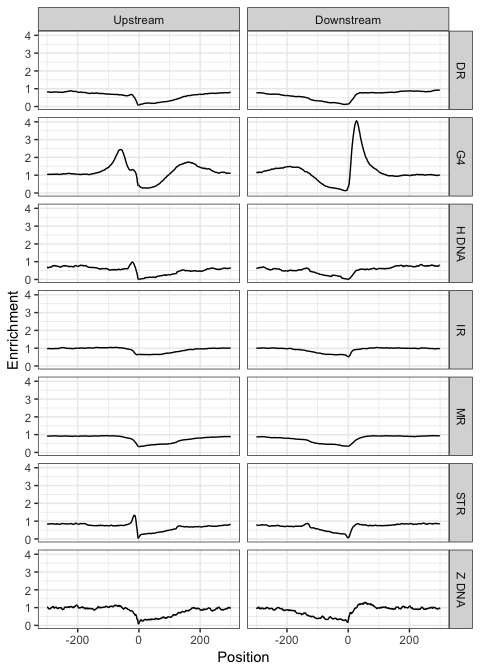

```r
G4.TOTAL[, Non_B:="G4"]
DR.TOTAL[, Non_B:="DR"]
H_DNA.TOTAL[, Non_B:="H DNA"]
IR.TOTAL[, Non_B:="IR"]
MR.TOTAL[, Non_B:="MR"]
STR.TOTAL[, Non_B:="STR"]
Z_DNA.TOTAL[, Non_B:="Z DNA"]
Non_B.TOTAL <- rbind(G4.TOTAL, DR.TOTAL, H_DNA.TOTAL, IR.TOTAL, MR.TOTAL, STR.TOTAL, Z_DNA.TOTAL)
Fig1.A <- ggplot(Non_B.TOTAL)+
    geom_line(aes(x=Position,y=Enrrichment)) +
    xlim(c(-300,300)) +
    facet_grid( Non_B ~ exon_pos ) +
  theme_bw()
Fig1.A
```

```r
Non_B.TOTAL.Enrrichment_Peak <- Non_B.TOTAL[ , .(Enrrichment_Peak=max(Enrrichment)) , by = c("Non_B", "exon_pos" )]
write.table(Non_B.TOTAL.Enrrichment_Peak, file = "./Tables/Non_B.TOTAL.Enrrichment_Peak.txt", append = FALSE, quote = FALSE, sep = "\t",
            eol = "\n", na = "NA", dec = ".", row.names = FALSE,
            col.names = TRUE, qmethod = c("escape", "double"),
            fileEncoding = "")
```

# Distribution of non-B DNA motifs across weak and strong splice sites

We calculated the distribution of non-B DNA motifs across quartiles of splice strength, where Q1 are the weakest splice sites and Q4 are the strongest.

```r
Merge_Qs <- function(Qs.list, window_len, strand ) {

  Total_Qs <- data.table(rbindlist(Qs.list))
  Q_names <- seq(nrow(Total_Qs)/window_len)
  Total_Qs[, Q:=rep(Q_names, each=window_len)]

  if(strand=="-"){

    Total_Qs[,Position:=Position*-1]
  }

  Total_Qs
}
```

```r
merge_plus_minus <- function(plus, minus){
  TOTAL <- merge(plus, minus, by=c("Position", "Q") )
  TOTAL[,Occurrences:=Occurrences.x+Occurrences.y]
  TOTAL[,median:=median(Occurrences),  by=c("Q")]
  TOTAL[, Enrrichment:=Occurrences/median]
  TOTAL[, Position:=Position-1]

}
```

```r
Merge_up_down <- function(Qs.up, Qs.down){
  Qs.total <- rbind(Qs.up, Qs.down)

  half_n <- nrow(Qs.total)/2
  Qs.total[, exon_pos:=rep(c("Upstream", "Downstream"), each=half_n) ]


  Qs.total$exon_pos <-  factor(Qs.total$exon_pos, levels=c("Upstream", "Downstream" ))
  Qs.total$Q <-  factor(Qs.total$Q)

  Qs.total

}
```

```r
get_total_Qs <- function(Qs.plus.up.list, Qs.minus.list, Qs.plus.down.list, Qs.minus.down.list, window_len){
  Qs.plus.up <- Merge_Qs(Qs.plus.up.list, window_len, strand="+")
  Qs.minus.up <- Merge_Qs(Qs.minus.list, window_len, strand="-")
  Qs.up <- merge_plus_minus(Qs.plus.up, Qs.minus.up)

  Qs.plus.down <- Merge_Qs(Qs.plus.down.list, window_len, strand="+")
  Qs.minus.down<- Merge_Qs(Qs.minus.down.list, window_len, strand="-")
  Qs.down <- merge_plus_minus(Qs.plus.down, Qs.minus.down)

  Qs.total <- Merge_up_down(Qs.up, Qs.down)

  Qs.total

}
```

```r
G4.Q1_up_plus <- read_dist_table("./All_non_Bs/q1_q4/exon.up_plus.q1.bed.G4.list.out.num")
```

[output not shown]

```r
G4.Q2_up_plus <- read_dist_table("./All_non_Bs/q1_q4/exon.up_plus.q2.bed.G4.list.out.num")
```

[output not shown]

```r
G4.Q3_up_plus <- read_dist_table("./All_non_Bs/q1_q4/exon.up_plus.q3.bed.G4.list.out.num")
```

[output not shown]

```r
G4.Q4_up_plus <- read_dist_table("./All_non_Bs/q1_q4/exon.up_plus.q4.bed.G4.list.out.num")
```

[output not shown]

```r
G4.Q1_down_plus <- read_dist_table("./All_non_Bs/q1_q4/exon.down_plus.q1.bed.G4.list.out.num")
```

[output not shown]

```r
G4.Q2_down_plus <- read_dist_table("./All_non_Bs/q1_q4/exon.down_plus.q2.bed.G4.list.out.num")
```

[output not shown]

```r
G4.Q3_down_plus <- read_dist_table("./All_non_Bs/q1_q4/exon.down_plus.q3.bed.G4.list.out.num")
```

[output not shown]

```r
G4.Q4_down_plus <- read_dist_table("./All_non_Bs/q1_q4/exon.down_plus.q4.bed.G4.list.out.num")
```

[output not shown]

```r
G4.Q1_up_minus <- read_dist_table("./All_non_Bs/q1_q4/exon.up_minus.q1.bed.G4.list.out.num")
```

[output not shown]

```r
G4.Q2_up_minus <- read_dist_table("./All_non_Bs/q1_q4/exon.up_minus.q2.bed.G4.list.out.num")
```

[output not shown]

```r
G4.Q3_up_minus <- read_dist_table("./All_non_Bs/q1_q4/exon.up_minus.q3.bed.G4.list.out.num")
```

[output not shown]

```r
G4.Q4_up_minus <- read_dist_table("./All_non_Bs/q1_q4/exon.up_minus.q4.bed.G4.list.out.num")
```

[output not shown]

```r
G4.Q1_down_minus <- read_dist_table("./All_non_Bs/q1_q4/exon.down_minus.q1.bed.G4.list.out.num")
```

[output not shown]

```r
G4.Q2_down_minus <- read_dist_table("./All_non_Bs/q1_q4/exon.down_minus.q2.bed.G4.list.out.num")
```

[output not shown]

```r
G4.Q3_down_minus <- read_dist_table("./All_non_Bs/q1_q4/exon.down_minus.q3.bed.G4.list.out.num")
```

[output not shown]

```r
G4.Q4_down_minus <- read_dist_table(".//All_non_Bs/q1_q4/exon.down_minus.q4.bed.G4.list.out.num")
```

[output not shown]

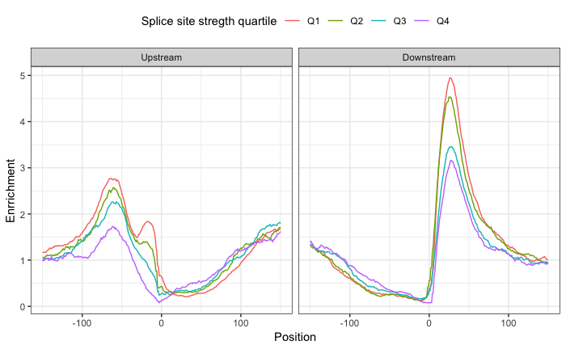

```r
G4.Qs.plus.up.list <- list(G4.Q1_up_plus, G4.Q2_up_plus, G4.Q3_up_plus, G4.Q4_up_plus)
G4.Qs.minus.list <- list(G4.Q1_up_minus, G4.Q2_up_minus, G4.Q3_up_minus, G4.Q4_up_minus)
G4.Qs.plus.down.list <- list(G4.Q1_down_plus, G4.Q2_down_plus, G4.Q3_down_plus, G4.Q4_down_plus)
G4.Qs.minus.down.list <- list(G4.Q1_down_minus, G4.Q2_down_minus, G4.Q3_down_minus, G4.Q4_down_minus)
G4.window_len = 2000
G4.Qs.total <- get_total_Qs(G4.Qs.plus.up.list, G4.Qs.minus.list, G4.Qs.plus.down.list, G4.Qs.minus.down.list, G4.window_len)
G4.Qs.total$Q <- mapvalues(G4.Qs.total$Q,  from =c(1:4), to =c("Q1", "Q2", "Q3", "Q4"))
ggplot(G4.Qs.total)+
  geom_line(aes(x=Position,y=Enrrichment, colour=Q)) +
  xlim(c(-150,150)) +
  facet_grid( . ~ exon_pos ) +
  theme(text = element_text(size=15)) +
  theme_bw()+labs(colour = "Splice site stregth quartile") +
   theme(legend.position = "top", legend.direction = "horizontal")
```

We calculated the binomial confidence intervals given the total number of exon in each quartile

```
Ignoring unknown aesthetics: y
```

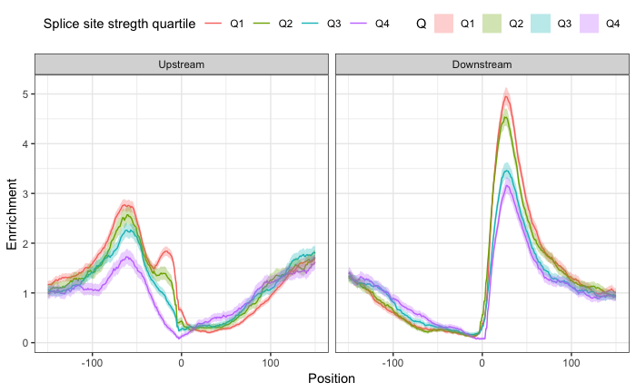

```r
hg19.nexons <- 123433 + 123936  #Number of exons found in each side
G4.Qs.total.binomial <- cbind(G4.Qs.total,  G4.Qs.total[, binconf(Occurrences, hg19.nexons/4) ])
G4.Qs.total.binomial[ , median:=median(PointEst), by=c("exon_pos", "Q")]
G4.Qs.total.binomial[, `:=`(Enrrichment=PointEst/median, Enrrichment_l=Lower/median, Enrrichment_u=Upper/median)]
ggplot(G4.Qs.total.binomial)+
  geom_line(aes(x=Position,y=Enrrichment, colour=Q)) +
  geom_ribbon(aes(x=Position,y=Enrrichment, fill=Q, ymin=Enrrichment_l, ymax=Enrrichment_u), alpha=0.3) +
  xlim(c(-150,150)) +
  facet_grid( . ~ exon_pos ) +
  theme(text = element_text(size=15)) +
  theme_bw()+labs(colour = "Splice site stregth quartile") +
   theme(legend.position = "top", legend.direction = "horizontal")
```

Then we explored the enrichment in other non-B DNA motifs

```r
DR.Q1_up_plus <- read_dist_table("./All_non_Bs/q1_q4/exon.up_plus.q1.bed.DRs.list.out.num")
DR.Q2_up_plus <- read_dist_table("./All_non_Bs/q1_q4/exon.up_plus.q2.bed.DRs.list.out.num")
DR.Q3_up_plus <- read_dist_table("./All_non_Bs/q1_q4/exon.up_plus.q3.bed.DRs.list.out.num")
DR.Q4_up_plus <- read_dist_table("./All_non_Bs/q1_q4/exon.up_plus.q4.bed.DRs.list.out.num")

DR.Q1_down_plus <- read_dist_table("./All_non_Bs/q1_q4/exon.down_plus.q1.bed.DRs.list.out.num")
DR.Q2_down_plus <- read_dist_table("./All_non_Bs/q1_q4/exon.down_plus.q2.bed.DRs.list.out.num")
DR.Q3_down_plus <- read_dist_table("./All_non_Bs/q1_q4/exon.down_plus.q3.bed.DRs.list.out.num")
DR.Q4_down_plus <- read_dist_table("./All_non_Bs/q1_q4/exon.down_plus.q4.bed.DRs.list.out.num")

DR.Q1_up_minus <- read_dist_table("./All_non_Bs/q1_q4/exon.up_minus.q1.bed.DRs.list.out.num")
DR.Q2_up_minus <- read_dist_table("./All_non_Bs/q1_q4/exon.up_minus.q2.bed.DRs.list.out.num")
DR.Q3_up_minus <- read_dist_table("./All_non_Bs/q1_q4/exon.up_minus.q3.bed.DRs.list.out.num")
DR.Q4_up_minus <- read_dist_table("./All_non_Bs/q1_q4/exon.up_minus.q4.bed.DRs.list.out.num")

DR.Q1_down_minus <- read_dist_table("./All_non_Bs/q1_q4/exon.down_minus.q1.bed.DRs.list.out.num")
DR.Q2_down_minus <- read_dist_table("./All_non_Bs/q1_q4/exon.down_minus.q2.bed.DRs.list.out.num")
DR.Q3_down_minus <- read_dist_table("./All_non_Bs/q1_q4/exon.down_minus.q3.bed.DRs.list.out.num")
DR.Q4_down_minus <- read_dist_table("./All_non_Bs/q1_q4/exon.down_minus.q4.bed.DRs.list.out.num")

DR.Qs.plus.up.list <- list(DR.Q1_up_plus, DR.Q2_up_plus, DR.Q3_up_plus, DR.Q4_up_plus)
DR.Qs.minus.list <- list(DR.Q1_up_minus, DR.Q2_up_minus, DR.Q3_up_minus, DR.Q4_up_minus)
DR.Qs.plus.down.list <- list(DR.Q1_down_plus, DR.Q2_down_plus, DR.Q3_down_plus, DR.Q4_down_plus)
DR.Qs.minus.down.list <- list(DR.Q1_down_minus, DR.Q2_down_minus, DR.Q3_down_minus, DR.Q4_down_minus)
DR.window_len = 2000

DR.Qs.total <- get_total_Qs(DR.Qs.plus.up.list, DR.Qs.minus.list, DR.Qs.plus.down.list, DR.Qs.minus.down.list, DR.window_len)
```

```r
H_DNA.Q1_up_plus <- read_dist_table("./All_non_Bs/q1_q4/exon.up_plus.q1.bed.H_DNA.list.out.num")
H_DNA.Q2_up_plus <- read_dist_table("./All_non_Bs/q1_q4/exon.up_plus.q2.bed.H_DNA.list.out.num")
H_DNA.Q3_up_plus <- read_dist_table("./All_non_Bs/q1_q4/exon.up_plus.q3.bed.H_DNA.list.out.num")
H_DNA.Q4_up_plus <- read_dist_table("./All_non_Bs/q1_q4/exon.up_plus.q4.bed.H_DNA.list.out.num")

H_DNA.Q1_down_plus <- read_dist_table("./All_non_Bs/q1_q4/exon.down_plus.q1.bed.H_DNA.list.out.num")
H_DNA.Q2_down_plus <- read_dist_table("./All_non_Bs/q1_q4/exon.down_plus.q2.bed.H_DNA.list.out.num")
H_DNA.Q3_down_plus <- read_dist_table("./All_non_Bs/q1_q4/exon.down_plus.q3.bed.H_DNA.list.out.num")
H_DNA.Q4_down_plus <- read_dist_table("./All_non_Bs/q1_q4/exon.down_plus.q4.bed.H_DNA.list.out.num")

H_DNA.Q1_up_minus <- read_dist_table("./All_non_Bs/q1_q4/exon.up_minus.q1.bed.H_DNA.list.out.num")
H_DNA.Q2_up_minus <- read_dist_table("./All_non_Bs/q1_q4/exon.up_minus.q2.bed.H_DNA.list.out.num")
H_DNA.Q3_up_minus <- read_dist_table("./All_non_Bs/q1_q4/exon.up_minus.q3.bed.H_DNA.list.out.num")
H_DNA.Q4_up_minus <- read_dist_table("./All_non_Bs/q1_q4/exon.up_minus.q4.bed.H_DNA.list.out.num")

H_DNA.Q1_down_minus <- read_dist_table("./All_non_Bs/q1_q4/exon.down_minus.q1.bed.H_DNA.list.out.num")
H_DNA.Q2_down_minus <- read_dist_table("./All_non_Bs/q1_q4/exon.down_minus.q2.bed.H_DNA.list.out.num")
H_DNA.Q3_down_minus <- read_dist_table("./All_non_Bs/q1_q4/exon.down_minus.q3.bed.H_DNA.list.out.num")
H_DNA.Q4_down_minus <- read_dist_table("./All_non_Bs/q1_q4/exon.down_minus.q4.bed.H_DNA.list.out.num")

H_DNA.Qs.plus.up.list <- list(H_DNA.Q1_up_plus, H_DNA.Q2_up_plus, H_DNA.Q3_up_plus, H_DNA.Q4_up_plus)
H_DNA.Qs.minus.list <- list(H_DNA.Q1_up_minus, H_DNA.Q2_up_minus, H_DNA.Q3_up_minus, H_DNA.Q4_up_minus)
H_DNA.Qs.plus.down.list <- list(H_DNA.Q1_down_plus, H_DNA.Q2_down_plus, H_DNA.Q3_down_plus, H_DNA.Q4_down_plus)
H_DNA.Qs.minus.down.list <- list(H_DNA.Q1_down_minus, H_DNA.Q2_down_minus, H_DNA.Q3_down_minus, H_DNA.Q4_down_minus)
H_DNA.window_len = 2000

H_DNA.Qs.total <- get_total_Qs(H_DNA.Qs.plus.up.list, H_DNA.Qs.minus.list, H_DNA.Qs.plus.down.list, H_DNA.Qs.minus.down.list, H_DNA.window_len)
```

```r
IR.Q1_up_plus <- read_dist_table("./All_non_Bs/q1_q4/exon.up_plus.q1.bed.IRs.list.out.num")
IR.Q2_up_plus <- read_dist_table("./All_non_Bs/q1_q4/exon.up_plus.q2.bed.IRs.list.out.num")
IR.Q3_up_plus <- read_dist_table("./All_non_Bs/q1_q4/exon.up_plus.q3.bed.IRs.list.out.num")
IR.Q4_up_plus <- read_dist_table("./All_non_Bs/q1_q4/exon.up_plus.q4.bed.IRs.list.out.num")

IR.Q1_down_plus <- read_dist_table("./All_non_Bs/q1_q4/exon.down_plus.q1.bed.IRs.list.out.num")
IR.Q2_down_plus <- read_dist_table("./All_non_Bs/q1_q4/exon.down_plus.q2.bed.IRs.list.out.num")
IR.Q3_down_plus <- read_dist_table("./All_non_Bs/q1_q4/exon.down_plus.q3.bed.IRs.list.out.num")
IR.Q4_down_plus <- read_dist_table("./All_non_Bs/q1_q4/exon.down_plus.q4.bed.IRs.list.out.num")

IR.Q1_up_minus <- read_dist_table("./All_non_Bs/q1_q4/exon.up_minus.q1.bed.IRs.list.out.num")
IR.Q2_up_minus <- read_dist_table("./All_non_Bs/q1_q4/exon.up_minus.q2.bed.IRs.list.out.num")
IR.Q3_up_minus <- read_dist_table("./All_non_Bs/q1_q4/exon.up_minus.q3.bed.IRs.list.out.num")
IR.Q4_up_minus <- read_dist_table("./All_non_Bs/q1_q4/exon.up_minus.q4.bed.IRs.list.out.num")

IR.Q1_down_minus <- read_dist_table("./All_non_Bs/q1_q4/exon.down_minus.q1.bed.IRs.list.out.num")
IR.Q2_down_minus <- read_dist_table("./All_non_Bs/q1_q4/exon.down_minus.q2.bed.IRs.list.out.num")
IR.Q3_down_minus <- read_dist_table("./All_non_Bs/q1_q4/exon.down_minus.q3.bed.IRs.list.out.num")
IR.Q4_down_minus <- read_dist_table("./All_non_Bs/q1_q4/exon.down_minus.q4.bed.IRs.list.out.num")

IR.Qs.plus.up.list <- list(IR.Q1_up_plus, IR.Q2_up_plus, IR.Q3_up_plus, IR.Q4_up_plus)
IR.Qs.minus.list <- list(IR.Q1_up_minus, IR.Q2_up_minus, IR.Q3_up_minus, IR.Q4_up_minus)
IR.Qs.plus.down.list <- list(IR.Q1_down_plus, IR.Q2_down_plus, IR.Q3_down_plus, IR.Q4_down_plus)
IR.Qs.minus.down.list <- list(IR.Q1_down_minus, IR.Q2_down_minus, IR.Q3_down_minus, IR.Q4_down_minus)
IR.window_len = 2000

IR.Qs.total <- get_total_Qs(IR.Qs.plus.up.list, IR.Qs.minus.list, IR.Qs.plus.down.list, IR.Qs.minus.down.list, IR.window_len)
```

```r
MR.Q1_up_plus <- read_dist_table("./All_non_Bs/q1_q4/exon.up_plus.q1.bed.MRs.list.out.num")
MR.Q2_up_plus <- read_dist_table("./All_non_Bs/q1_q4/exon.up_plus.q2.bed.MRs.list.out.num")
MR.Q3_up_plus <- read_dist_table("./All_non_Bs/q1_q4/exon.up_plus.q3.bed.MRs.list.out.num")
MR.Q4_up_plus <- read_dist_table("./All_non_Bs/q1_q4/exon.up_plus.q4.bed.MRs.list.out.num")

MR.Q1_down_plus <- read_dist_table("./All_non_Bs/q1_q4/exon.down_plus.q1.bed.MRs.list.out.num")
MR.Q2_down_plus <- read_dist_table("./All_non_Bs/q1_q4/exon.down_plus.q2.bed.MRs.list.out.num")
MR.Q3_down_plus <- read_dist_table("./All_non_Bs/q1_q4/exon.down_plus.q3.bed.MRs.list.out.num")
MR.Q4_down_plus <- read_dist_table("./All_non_Bs/q1_q4/exon.down_plus.q4.bed.MRs.list.out.num")

MR.Q1_up_minus <- read_dist_table("./All_non_Bs/q1_q4/exon.up_minus.q1.bed.MRs.list.out.num")
MR.Q2_up_minus <- read_dist_table("./All_non_Bs/q1_q4/exon.up_minus.q2.bed.MRs.list.out.num")
MR.Q3_up_minus <- read_dist_table("./All_non_Bs/q1_q4/exon.up_minus.q3.bed.MRs.list.out.num")
MR.Q4_up_minus <- read_dist_table("./All_non_Bs/q1_q4/exon.up_minus.q4.bed.MRs.list.out.num")

MR.Q1_down_minus <- read_dist_table("./All_non_Bs/q1_q4/exon.down_minus.q1.bed.MRs.list.out.num")
MR.Q2_down_minus <- read_dist_table("./All_non_Bs/q1_q4/exon.down_minus.q2.bed.MRs.list.out.num")
MR.Q3_down_minus <- read_dist_table("./All_non_Bs/q1_q4/exon.down_minus.q3.bed.MRs.list.out.num")
MR.Q4_down_minus <- read_dist_table("./All_non_Bs/q1_q4/exon.down_minus.q4.bed.MRs.list.out.num")

MR.Qs.plus.up.list <- list(MR.Q1_up_plus, MR.Q2_up_plus, MR.Q3_up_plus, MR.Q4_up_plus)
MR.Qs.minus.list <- list(MR.Q1_up_minus, MR.Q2_up_minus, MR.Q3_up_minus, MR.Q4_up_minus)
MR.Qs.plus.down.list <- list(MR.Q1_down_plus, MR.Q2_down_plus, MR.Q3_down_plus, MR.Q4_down_plus)
MR.Qs.minus.down.list <- list(MR.Q1_down_minus, MR.Q2_down_minus, MR.Q3_down_minus, MR.Q4_down_minus)
MR.window_len = 2000

MR.Qs.total <- get_total_Qs(MR.Qs.plus.up.list, MR.Qs.minus.list, MR.Qs.plus.down.list, MR.Qs.minus.down.list, MR.window_len)
```

```r
STR.Q1_up_plus <- read_dist_table("./All_non_Bs/q1_q4/exon.up_plus.q1.bed.STRs.list.out.num")
STR.Q2_up_plus <- read_dist_table("./All_non_Bs/q1_q4/exon.up_plus.q2.bed.STRs.list.out.num")
STR.Q3_up_plus <- read_dist_table("./All_non_Bs/q1_q4/exon.up_plus.q3.bed.STRs.list.out.num")
STR.Q4_up_plus <- read_dist_table("./All_non_Bs/q1_q4/exon.up_plus.q4.bed.STRs.list.out.num")

STR.Q1_down_plus <- read_dist_table("./All_non_Bs/q1_q4/exon.down_plus.q1.bed.STRs.list.out.num")
STR.Q2_down_plus <- read_dist_table("./All_non_Bs/q1_q4/exon.down_plus.q2.bed.STRs.list.out.num")
STR.Q3_down_plus <- read_dist_table("./All_non_Bs/q1_q4/exon.down_plus.q3.bed.STRs.list.out.num")
STR.Q4_down_plus <- read_dist_table("./All_non_Bs/q1_q4/exon.down_plus.q4.bed.STRs.list.out.num")

STR.Q1_up_minus <- read_dist_table("./All_non_Bs/q1_q4/exon.up_minus.q1.bed.STRs.list.out.num")
STR.Q2_up_minus <- read_dist_table("./All_non_Bs/q1_q4/exon.up_minus.q2.bed.STRs.list.out.num")
STR.Q3_up_minus <- read_dist_table("./All_non_Bs/q1_q4/exon.up_minus.q3.bed.STRs.list.out.num")
STR.Q4_up_minus <- read_dist_table("./All_non_Bs/q1_q4/exon.up_minus.q4.bed.STRs.list.out.num")

STR.Q1_down_minus <- read_dist_table("./All_non_Bs/q1_q4/exon.down_minus.q1.bed.STRs.list.out.num")
STR.Q2_down_minus <- read_dist_table("./All_non_Bs/q1_q4/exon.down_minus.q2.bed.STRs.list.out.num")
STR.Q3_down_minus <- read_dist_table("./All_non_Bs/q1_q4/exon.down_minus.q3.bed.STRs.list.out.num")
STR.Q4_down_minus <- read_dist_table("./All_non_Bs/q1_q4/exon.down_minus.q4.bed.STRs.list.out.num")

STR.Qs.plus.up.list <- list(STR.Q1_up_plus, STR.Q2_up_plus, STR.Q3_up_plus, STR.Q4_up_plus)
STR.Qs.minus.list <- list(STR.Q1_up_minus, STR.Q2_up_minus, STR.Q3_up_minus, STR.Q4_up_minus)
STR.Qs.plus.down.list <- list(STR.Q1_down_plus, STR.Q2_down_plus, STR.Q3_down_plus, STR.Q4_down_plus)
STR.Qs.minus.down.list <- list(STR.Q1_down_minus, STR.Q2_down_minus, STR.Q3_down_minus, STR.Q4_down_minus)
STR.window_len = 2000

STR.Qs.total <- get_total_Qs(STR.Qs.plus.up.list, STR.Qs.minus.list, STR.Qs.plus.down.list, STR.Qs.minus.down.list, STR.window_len)
```

```r
Z_DNA.Q1_up_plus <- read_dist_table("./All_non_Bs/q1_q4/exon.up_plus.q1.bed.Z_DNA.list.out.num")
Z_DNA.Q2_up_plus <- read_dist_table("./All_non_Bs/q1_q4/exon.up_plus.q2.bed.Z_DNA.list.out.num")
Z_DNA.Q3_up_plus <- read_dist_table("./All_non_Bs/q1_q4/exon.up_plus.q3.bed.Z_DNA.list.out.num")
Z_DNA.Q4_up_plus <- read_dist_table("./All_non_Bs/q1_q4/exon.up_plus.q4.bed.Z_DNA.list.out.num")

Z_DNA.Q1_down_plus <- read_dist_table("./All_non_Bs/q1_q4/exon.down_plus.q1.bed.Z_DNA.list.out.num")
Z_DNA.Q2_down_plus <- read_dist_table("./All_non_Bs/q1_q4/exon.down_plus.q2.bed.Z_DNA.list.out.num")
Z_DNA.Q3_down_plus <- read_dist_table("./All_non_Bs/q1_q4/exon.down_plus.q3.bed.Z_DNA.list.out.num")
Z_DNA.Q4_down_plus <- read_dist_table("./All_non_Bs/q1_q4/exon.down_plus.q4.bed.Z_DNA.list.out.num")

Z_DNA.Q1_up_minus <- read_dist_table("./All_non_Bs/q1_q4/exon.up_minus.q1.bed.Z_DNA.list.out.num")
Z_DNA.Q2_up_minus <- read_dist_table("./All_non_Bs/q1_q4/exon.up_minus.q2.bed.Z_DNA.list.out.num")
Z_DNA.Q3_up_minus <- read_dist_table("./All_non_Bs/q1_q4/exon.up_minus.q3.bed.Z_DNA.list.out.num")
Z_DNA.Q4_up_minus <- read_dist_table("./All_non_Bs/q1_q4/exon.up_minus.q4.bed.Z_DNA.list.out.num")

Z_DNA.Q1_down_minus <- read_dist_table("./All_non_Bs/q1_q4/exon.down_minus.q1.bed.Z_DNA.list.out.num")
Z_DNA.Q2_down_minus <- read_dist_table("./All_non_Bs/q1_q4/exon.down_minus.q2.bed.Z_DNA.list.out.num")
Z_DNA.Q3_down_minus <- read_dist_table("./All_non_Bs/q1_q4/exon.down_minus.q3.bed.Z_DNA.list.out.num")
Z_DNA.Q4_down_minus <- read_dist_table("./All_non_Bs/q1_q4/exon.down_minus.q4.bed.Z_DNA.list.out.num")

Z_DNA.Qs.plus.up.list <- list(Z_DNA.Q1_up_plus, Z_DNA.Q2_up_plus, Z_DNA.Q3_up_plus, Z_DNA.Q4_up_plus)
Z_DNA.Qs.minus.list <- list(Z_DNA.Q1_up_minus, Z_DNA.Q2_up_minus, Z_DNA.Q3_up_minus, Z_DNA.Q4_up_minus)
Z_DNA.Qs.plus.down.list <- list(Z_DNA.Q1_down_plus, Z_DNA.Q2_down_plus, Z_DNA.Q3_down_plus, Z_DNA.Q4_down_plus)
Z_DNA.Qs.minus.down.list <- list(Z_DNA.Q1_down_minus, Z_DNA.Q2_down_minus, Z_DNA.Q3_down_minus, Z_DNA.Q4_down_minus)
Z_DNA.window_len = 2000

Z_DNA.Qs.total <- get_total_Qs(Z_DNA.Qs.plus.up.list, Z_DNA.Qs.minus.list, Z_DNA.Qs.plus.down.list, Z_DNA.Qs.minus.down.list, Z_DNA.window_len)
```

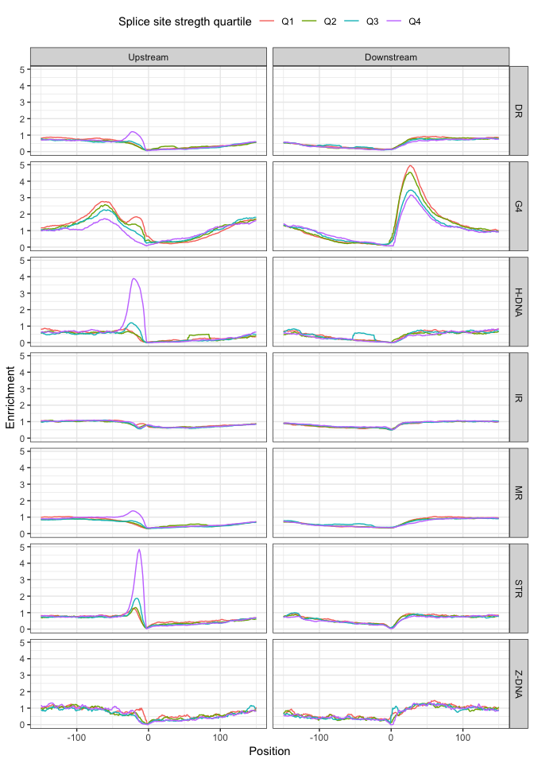

```r
G4.Qs.total[, Non_B:="G4"]
DR.Qs.total[, Non_B:="DR"]
H_DNA.Qs.total[, Non_B:="H-DNA"]
IR.Qs.total[, Non_B:="IR"]
MR.Qs.total[, Non_B:="MR"]
STR.Qs.total[, Non_B:="STR"]
Z_DNA.Qs.total[, Non_B:="Z-DNA"]
Non_B.Qs.TOTAL <- rbind(G4.Qs.total, DR.Qs.total, H_DNA.Qs.total, IR.Qs.total, MR.Qs.total, STR.Qs.total, Z_DNA.Qs.total)
Non_B.Qs.TOTAL$Q <- mapvalues(Non_B.Qs.TOTAL$Q,  from =c(1:4), to =c("Q1", "Q2", "Q3", "Q4"))
ggplot(Non_B.Qs.TOTAL)+
  geom_line(aes(x=Position,y=Enrrichment, colour=Q)) +
  xlim(c(-150,150)) +
  facet_grid( Non_B ~ exon_pos ) +
  labs(colour = "Splice site stregth quartile") +
  theme_bw()  +
  theme(legend.position = "top", legend.direction = "horizontal")
```

```r
Non_B.Qs.TOTAL.Enrrichment_Peak <- Non_B.Qs.TOTAL[  , .(Enrrichment_Peak=max(Enrrichment)) , by= c("Non_B", "exon_pos", "Q")]
write.table(Non_B.Qs.TOTAL.Enrrichment_Peak, file = "./Tables/Non_B.Qs.TOTAL.Enrrichment_Peak.txt", append = FALSE, quote = FALSE, sep = "\t",
            eol = "\n", na = "NA", dec = ".", row.names = FALSE,
            col.names = TRUE, qmethod = c("escape", "double"),
            fileEncoding = "")
```

# Template - non template

To investigate if the distribution of non-B DNA motifs is biased by transcription direction, we generate `.num` files where the counts were separated by template and non templated strands:

- Template = plus_minus, minus_plus
- Non-template = minus_minus, plus_plus

```r
G4.template.Q1_up_plus <- read_dist_table("./template_non_template/exon.up_plus.q1.bed.G4s_minus_plus.list.final.num")
G4.template.Q2_up_plus <- read_dist_table("./template_non_template/exon.up_plus.q2.bed.G4s_minus_plus.list.final.num")
G4.template.Q3_up_plus <- read_dist_table("./template_non_template/exon.up_plus.q3.bed.G4s_minus_plus.list.final.num")
G4.template.Q4_up_plus <- read_dist_table("./template_non_template/exon.up_plus.q4.bed.G4s_minus_plus.list.final.num")

G4.template.Q1_up_minus <- read_dist_table("./template_non_template/exon.up_minus.q1.bed.G4s_plus_minus.list.final.num")
G4.template.Q2_up_minus <- read_dist_table("./template_non_template/exon.up_minus.q2.bed.G4s_plus_minus.list.final.num")
G4.template.Q3_up_minus <- read_dist_table("./template_non_template/exon.up_minus.q3.bed.G4s_plus_minus.list.final.num")
G4.template.Q4_up_minus <- read_dist_table("./template_non_template/exon.up_minus.q4.bed.G4s_plus_minus.list.final.num")

G4.template.Q1_down_plus <- read_dist_table("./template_non_template/exon.down_plus.q1.bed.G4s_minus_plus.list.final.num")
G4.template.Q2_down_plus <- read_dist_table("./template_non_template/exon.down_plus.q2.bed.G4s_minus_plus.list.final.num")
G4.template.Q3_down_plus <- read_dist_table("./template_non_template/exon.down_plus.q3.bed.G4s_minus_plus.list.final.num")
G4.template.Q4_down_plus <- read_dist_table("./template_non_template/exon.down_plus.q4.bed.G4s_minus_plus.list.final.num")

G4.template.Q1_down_minus <- read_dist_table("./template_non_template/exon.down_minus.q1.bed.G4s_plus_minus.list.final.num")
G4.template.Q2_down_minus <- read_dist_table("./template_non_template/exon.down_minus.q2.bed.G4s_plus_minus.list.final.num")
G4.template.Q3_down_minus <- read_dist_table("./template_non_template/exon.down_minus.q3.bed.G4s_plus_minus.list.final.num")
G4.template.Q4_down_minus <- read_dist_table("./template_non_template/exon.down_minus.q4.bed.G4s_plus_minus.list.final.num")


G4.non_template.Q1_up_plus <- read_dist_table("./template_non_template/exon.up_plus.q1.bed.G4s_plus_plus.list.final.num")
G4.non_template.Q2_up_plus <- read_dist_table("./template_non_template/exon.up_plus.q2.bed.G4s_plus_plus.list.final.num")
G4.non_template.Q3_up_plus <- read_dist_table("./template_non_template/exon.up_plus.q3.bed.G4s_plus_plus.list.final.num")
G4.non_template.Q4_up_plus <- read_dist_table("./template_non_template/exon.up_plus.q4.bed.G4s_plus_plus.list.final.num")

G4.non_template.Q1_up_minus <- read_dist_table("./template_non_template/exon.up_minus.q1.bed.G4s_minus_minus.list.final.num")
G4.non_template.Q2_up_minus <- read_dist_table("./template_non_template/exon.up_minus.q2.bed.G4s_minus_minus.list.final.num")
G4.non_template.Q3_up_minus <- read_dist_table("./template_non_template/exon.up_minus.q3.bed.G4s_minus_minus.list.final.num")
G4.non_template.Q4_up_minus <- read_dist_table("./template_non_template/exon.up_minus.q4.bed.G4s_minus_minus.list.final.num")

G4.non_template.Q1_down_plus <- read_dist_table("./template_non_template/exon.down_plus.q1.bed.G4s_plus_plus.list.final.num")
G4.non_template.Q2_down_plus <- read_dist_table("./template_non_template/exon.down_plus.q2.bed.G4s_plus_plus.list.final.num")
G4.non_template.Q3_down_plus <- read_dist_table("./template_non_template/exon.down_plus.q3.bed.G4s_plus_plus.list.final.num")
G4.non_template.Q4_down_plus <- read_dist_table("./template_non_template/exon.down_plus.q4.bed.G4s_plus_plus.list.final.num")

G4.non_template.Q1_down_minus <- read_dist_table("./template_non_template/exon.down_minus.q1.bed.G4s_minus_minus.list.final.num")
G4.non_template.Q2_down_minus <- read_dist_table("./template_non_template/exon.down_minus.q2.bed.G4s_minus_minus.list.final.num")
G4.non_template.Q3_down_minus <- read_dist_table("./template_non_template/exon.down_minus.q3.bed.G4s_minus_minus.list.final.num")
G4.non_template.Q4_down_minus <- read_dist_table("./template_non_template/exon.down_minus.q4.bed.G4s_minus_minus.list.final.num")
```

```r
G4.template.Qs.plus.up.list <- list(G4.template.Q1_up_plus, G4.template.Q2_up_plus, G4.template.Q3_up_plus, G4.template.Q4_up_plus)
G4.template.Qs.minus.list <- list(G4.template.Q1_up_minus, G4.template.Q2_up_minus, G4.template.Q3_up_minus, G4.template.Q4_up_minus)
G4.template.Qs.plus.down.list <- list(G4.template.Q1_down_plus, G4.template.Q2_down_plus, G4.template.Q3_down_plus, G4.template.Q4_down_plus)
G4.template.Qs.minus.down.list <- list(G4.template.Q1_down_minus, G4.template.Q2_down_minus, G4.template.Q3_down_minus, G4.template.Q4_down_minus)
G4.template.window_len = 2000
G4.template.Qs.total <- get_total_Qs(G4.template.Qs.plus.up.list, G4.template.Qs.minus.list, G4.template.Qs.plus.down.list, G4.template.Qs.minus.down.list, G4.template.window_len)
```

```r
G4.non_template.Qs.plus.up.list <- list(G4.non_template.Q1_up_plus, G4.non_template.Q2_up_plus, G4.non_template.Q3_up_plus, G4.non_template.Q4_up_plus)
G4.non_template.Qs.minus.list <- list(G4.non_template.Q1_up_minus, G4.non_template.Q2_up_minus, G4.non_template.Q3_up_minus, G4.non_template.Q4_up_minus)
G4.non_template.Qs.plus.down.list <- list(G4.non_template.Q1_down_plus, G4.non_template.Q2_down_plus, G4.non_template.Q3_down_plus, G4.non_template.Q4_down_plus)
G4.non_template.Qs.minus.down.list <- list(G4.non_template.Q1_down_minus, G4.non_template.Q2_down_minus, G4.non_template.Q3_down_minus, G4.non_template.Q4_down_minus)
G4.non_template.window_len = 2000
G4.non_template.Qs.total <- get_total_Qs(G4.non_template.Qs.plus.up.list, G4.non_template.Qs.minus.list, G4.non_template.Qs.plus.down.list, G4.non_template.Qs.minus.down.list, G4.template.window_len)
```

```r
G4.template.Qs.total
G4.non_template.Qs.total


G4.template_non_template.Qs.total <- rbind(G4.template.Qs.total, G4.non_template.Qs.total)

half_n <- nrow(G4.template_non_template.Qs.total)/2
G4.template_non_template.Qs.total[, Strand:=rep(c("Template", "Non-template"), each=half_n) ]




G4.template_non_template.Qs.total$Strand <-  factor(G4.template_non_template.Qs.total$Strand, levels=c("Template", "Non-template" ))
```

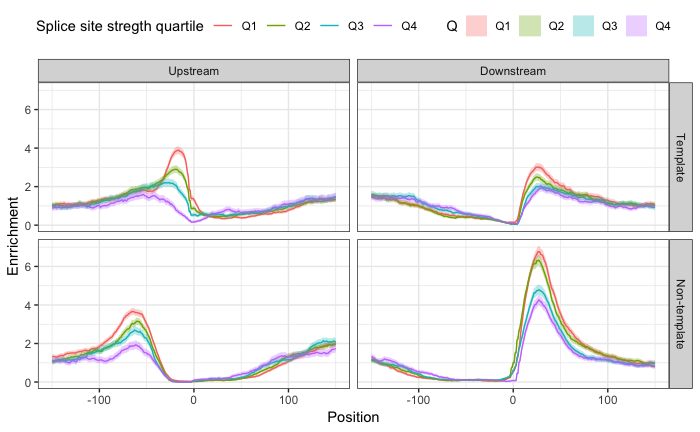

```r
G4.template_non_template.Qs.total$Q <- mapvalues(G4.template_non_template.Qs.total$Q,  from =c(1:4), to =c("Q1", "Q2", "Q3", "Q4"))
G4.template_non_template.Qs.total.binomial <- cbind(G4.template_non_template.Qs.total,  G4.template_non_template.Qs.total[, binconf(Occurrences, hg19.nexons/8) ])
G4.template_non_template.Qs.total.binomial[, median:=NULL]
G4.template_non_template.Qs.total.binomial[ , median:=median(PointEst), by=c("exon_pos", "Q", "Strand")]
G4.template_non_template.Qs.total.binomial[, `:=`(Enrrichment=PointEst/median, Enrrichment_l=Lower/median, Enrrichment_u=Upper/median)]
Fig2.A <- ggplot(G4.template_non_template.Qs.total.binomial)+
  geom_line(aes(x=Position,y=Enrrichment, colour=Q)) +
   geom_ribbon(aes(x=Position, fill=Q, ymin=Enrrichment_l, ymax=Enrrichment_u), alpha=0.3) +
  xlim(c(-150,150)) +
  facet_grid( Strand ~ exon_pos ) +
  labs(colour = "Splice site stregth quartile") +
  theme_bw()  +
  theme(legend.position = "top", legend.direction = "horizontal")
Fig2.A
```

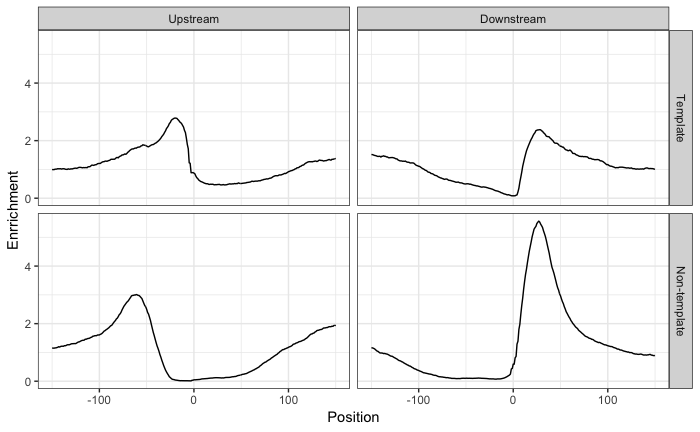

```r
G4.template_non_template.total <- G4.template_non_template.Qs.total[ , .(Occurrences=sum(Occurrences)) , by=c("Strand", "exon_pos", "Position")]
G4.template_non_template.total[ , median:=median(Occurrences) , by=c("Strand", "exon_pos")]
G4.template_non_template.total[ , Enrrichment:=Occurrences/median , by=c("Strand", "exon_pos", "Position")]
ggplot(G4.template_non_template.total)+
  geom_line(aes(x=Position,y=Enrrichment)) +
  xlim(c(-150,150)) +
  facet_grid( Strand ~ exon_pos ) +
  labs(colour = "Splice site stregth quartile") +
  theme_bw()  +
  theme(legend.position = "top", legend.direction = "horizontal")
```

```r
G4.template_non_template.total_Peak <- G4.template_non_template.total[  , .(Enrrichment_Peak=max(Enrrichment)) , by= c("Strand", "exon_pos")]
write.table(G4.template_non_template.total_Peak, file = "./Tables/G4.template_non_template.total_Peak.txt", append = FALSE, quote = FALSE, sep = "\t",
            eol = "\n", na = "NA", dec = ".", row.names = FALSE,
            col.names = TRUE, qmethod = c("escape", "double"),
            fileEncoding = "")
```

```r
G4.template_non_template.Qs.total.Enrrichment_Peak <- G4.template_non_template.Qs.total[  , .(Enrrichment_Peak=max(Enrrichment)) , by= c( "exon_pos", "Q", "Strand" )]
write.table(G4.template_non_template.Qs.total.Enrrichment_Peak, file = "./Tables/G4.template_non_template.Qs.total.Enrrichment_Peak.txt", append = FALSE, quote = FALSE, sep = "\t",
            eol = "\n", na = "NA", dec = ".", row.names = FALSE,
            col.names = TRUE, qmethod = c("escape", "double"),
            fileEncoding = "")
```

# G4 RUNS

Here we explored the enrichment of G-quadruplexes with different G-run length

```r
G1_up_plus <- read_dist_table("./G4_runs/exon.up_plus.bed.Single_G_runs.list.out.num")
G2_up_plus <- read_dist_table("./G4_runs/exon.up_plus.bed.Twice_G_runs.list.out.num")
G3_up_plus <- read_dist_table("./G4_runs/exon.up_plus.bed.Three_G_runs.list.out.num")
G4_up_plus <- read_dist_table("./G4_runs/exon.up_plus.bed.Four_G_runs.list.out.num")
G5_up_plus <- read_dist_table("./G4_runs/exon.up_plus.bed.Five_G_runs.list.out.num")
G6_up_plus <- read_dist_table("./G4_runs/exon.up_plus.bed.Six_G_runs.list.out.num")
G1_up_minus <- read_dist_table("./G4_runs/exon.up_minus.bed.Single_G_runs.list.out.num")
G2_up_minus <- read_dist_table("./G4_runs/exon.up_minus.bed.Twice_G_runs.list.out.num")
G3_up_minus <- read_dist_table("./G4_runs/exon.up_minus.bed.Three_G_runs.list.out.num")
G4_up_minus <- read_dist_table("./G4_runs/exon.up_minus.bed.Four_G_runs.list.out.num")
G5_up_minus <- read_dist_table("./G4_runs/exon.up_minus.bed.Five_G_runs.list.out.num")
G6_up_minus <- read_dist_table("./G4_runs/exon.up_minus.bed.Six_G_runs.list.out.num")
G1_down_plus <- read_dist_table("./G4_runs/exon.down_plus.bed.Single_G_runs.list.out.num")
G2_down_plus <- read_dist_table("./G4_runs/exon.down_plus.bed.Twice_G_runs.list.out.num")
G3_down_plus <- read_dist_table("./G4_runs/exon.down_plus.bed.Three_G_runs.list.out.num")
G4_down_plus <- read_dist_table("./G4_runs/exon.down_plus.bed.Four_G_runs.list.out.num")
G5_down_plus <- read_dist_table("./G4_runs/exon.down_plus.bed.Five_G_runs.list.out.num")
G6_down_plus <- read_dist_table("./G4_runs/exon.down_plus.bed.Six_G_runs.list.out.num")
G1_down_minus <- read_dist_table("./G4_runs/exon.down_minus.bed.Single_G_runs.list.out.num")
G2_down_minus <- read_dist_table("./G4_runs/exon.down_minus.bed.Twice_G_runs.list.out.num")
G3_down_minus <- read_dist_table("./G4_runs/exon.down_minus.bed.Three_G_runs.list.out.num")
G4_down_minus <- read_dist_table("./G4_runs/exon.down_minus.bed.Four_G_runs.list.out.num")
G5_down_minus <- read_dist_table("./G4_runs/exon.down_minus.bed.Five_G_runs.list.out.num")
G6_down_minus <- read_dist_table("./G4_runs/exon.down_minus.bed.Six_G_runs.list.out.num")
```

```r
Gruns.up_plus.list <- list(G1_up_plus, G2_up_plus, G3_up_plus, G4_up_plus, G5_up_plus, G6_up_plus)
Gruns.up_minus.list <- list(G1_up_minus, G2_up_minus, G3_up_minus, G4_up_minus, G5_up_minus, G6_up_minus)
Gruns.down_plus.list <- list(G1_down_plus, G2_down_plus, G3_down_plus, G4_down_plus, G5_down_plus, G6_down_plus)
Gruns.down_minus.list <- list(G1_down_minus, G2_down_minus, G3_down_minus, G4_down_minus, G5_down_minus, G6_down_minus)
Gruns.window_len = 2000
Gruns.total <- get_total_Qs(Gruns.up_plus.list, Gruns.up_minus.list, Gruns.down_plus.list, Gruns.down_minus.list, Gruns.window_len)
Gruns.total[, G_run_length:=Q]
```

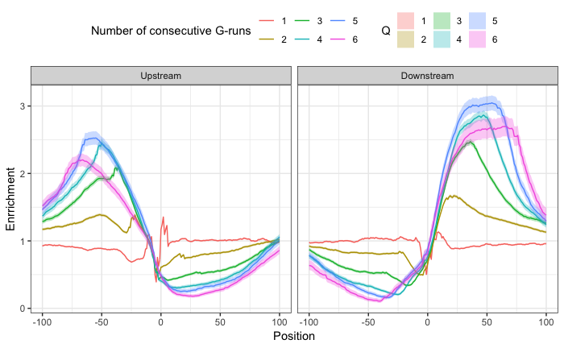

```r
Gruns.total.binomial <- cbind(Gruns.total,  Gruns.total[, binconf(Occurrences, hg19.nexons) ])
Gruns.total.binomial[, median:=NULL]
Gruns.total.binomial[ , median:=median(PointEst), by=c("exon_pos", "Q" )]
Gruns.total.binomial[, `:=`(Enrrichment=PointEst/median, Enrrichment_l=Lower/median, Enrrichment_u=Upper/median)]
Fig2.B <- ggplot(Gruns.total.binomial)+
  geom_line(aes(x=Position,y=Enrrichment, colour=G_run_length)) +
  geom_ribbon(aes(x=Position, fill=Q, ymin=Enrrichment_l, ymax=Enrrichment_u), alpha=0.3) +
  xlim(c(-100,100)) +
  facet_grid( . ~ exon_pos ) +
  theme(text = element_text(size=15)) +
  theme_bw() +
  labs(colour = "Number of consecutive G-runs") +
  theme(legend.position = "top", legend.direction = "horizontal")
Fig2.B
```

```r
Gruns.total.Enrrichment_Peak <- Gruns.total[  , .(Enrrichment_Peak=max(Enrrichment)) , by= c( "exon_pos", "G_run_length")]
write.table(Gruns.total.Enrrichment_Peak, file = "./Tables/Gruns.total.Enrrichment_Peak.txt", append = FALSE, quote = FALSE, sep = "\t",
            eol = "\n", na = "NA", dec = ".", row.names = FALSE,
            col.names = TRUE, qmethod = c("escape", "double"),
            fileEncoding = "")
```

## G4 enrichment across evolution

We analyzed the G4 enrichment across splice sites from different species

```r
susScr11.up_plus <- read_dist_table("./Evolution/susScr11.exon.up_plus.bed.score.susScr11.txt..list.out.num")
susScr11.down_plus <- read_dist_table("./Evolution/susScr11.exon.down_plus.bed.score.susScr11.txt..list.out.num")
susScr11.up_minus <- read_dist_table("./Evolution/susScr11.exon.up_minus.bed.score.susScr11.txt..list.out.num")
susScr11.down_minus <- read_dist_table("./Evolution/susScr11.exon.down_minus.bed.score.susScr11.txt..list.out.num")
susScr11.up_minus[,Position:=Position*-1]
susScr11.down_minus[,Position:=Position*-1]
susScr11.TOTAL <- plot_density(susScr11.up_plus, susScr11.up_minus, susScr11.down_plus, susScr11.down_minus)
```

```r
TAIR10.up_plus <- read_dist_table("./Evolution/TAIR10.exon.up_plus.bed.score.TAIR10.txt..list.out.num")
TAIR10.down_plus <- read_dist_table("./Evolution/TAIR10.exon.down_plus.bed.score.TAIR10.txt..list.out.num")
TAIR10.up_minus <- read_dist_table("./Evolution/TAIR10.exon.up_minus.bed.score.TAIR10.txt..list.out.num")
TAIR10.down_minus <- read_dist_table("./Evolution/TAIR10.exon.down_minus.bed.score.TAIR10.txt..list.out.num")
TAIR10.up_minus[,Position:=Position*-1]
TAIR10.down_minus[,Position:=Position*-1]
TAIR10.TOTAL <- plot_density(TAIR10.up_plus, TAIR10.up_minus, TAIR10.down_plus, TAIR10.down_minus)
```

```r
anoCar2.up_plus <- read_dist_table("./Evolution/anoCar2.exon.up_plus.bed.score.anoCar2.txt..list.out.num")
anoCar2.down_plus <- read_dist_table("./Evolution/anoCar2.exon.down_plus.bed.score.anoCar2.txt..list.out.num")
anoCar2.up_minus <- read_dist_table("./Evolution/anoCar2.exon.up_minus.bed.score.anoCar2.txt..list.out.num")
anoCar2.down_minus <- read_dist_table("./Evolution/anoCar2.exon.down_minus.bed.score.anoCar2.txt..list.out.num")
anoCar2.up_minus[,Position:=Position*-1]
anoCar2.down_minus[,Position:=Position*-1]
anoCar2.TOTAL <- plot_density(anoCar2.up_plus, anoCar2.up_minus, anoCar2.down_plus, anoCar2.down_minus)
```

```r
xenTro9.up_plus <- read_dist_table("./Evolution/xenTro9.exon.up_plus.bed.score.xenTro9.txt..list.out.num")
xenTro9.down_plus <- read_dist_table("./Evolution/xenTro9.exon.down_plus.bed.score.xenTro9.txt..list.out.num")
xenTro9.up_minus <- read_dist_table("./Evolution/xenTro9.exon.up_minus.bed.score.xenTro9.txt..list.out.num")
xenTro9.down_minus <- read_dist_table("./Evolution/xenTro9.exon.down_minus.bed.score.xenTro9.txt..list.out.num")
xenTro9.up_minus[,Position:=Position*-1]
xenTro9.down_minus[,Position:=Position*-1]
xenTro9.TOTAL <- plot_density(xenTro9.up_plus, xenTro9.up_minus, xenTro9.down_plus, xenTro9.down_minus)
```

```r
ce10.up_plus <- read_dist_table("./Evolution/ce10.exon.up_plus.bed.score.ce10.txt..list.out.num")
ce10.down_plus <- read_dist_table("./Evolution/ce10.exon.down_plus.bed.score.ce10.txt..list.out.num")
ce10.up_minus <- read_dist_table("./Evolution/ce10.exon.up_minus.bed.score.ce10.txt..list.out.num")
ce10.down_minus <- read_dist_table("./Evolution/ce10.exon.down_minus.bed.score.ce10.txt..list.out.num")
ce10.up_minus[,Position:=Position*-1]
ce10.down_minus[,Position:=Position*-1]
ce10.TOTAL <- plot_density(ce10.up_plus, ce10.up_minus, ce10.down_plus, ce10.down_minus)
```

```r
danRer11.up_plus <- read_dist_table("./Evolution/danRer11.exon.up_plus.bed.score.danRer11.txt..list.out.num")
danRer11.down_plus <- read_dist_table("./Evolution/danRer11.exon.down_plus.bed.score.danRer11.txt..list.out.num")
danRer11.up_minus <- read_dist_table("./Evolution/danRer11.exon.up_minus.bed.score.danRer11.txt..list.out.num")
danRer11.down_minus <- read_dist_table("./Evolution/danRer11.exon.down_minus.bed.score.danRer11.txt..list.out.num")
danRer11.up_minus[,Position:=Position*-1]
danRer11.down_minus[,Position:=Position*-1]
danRer11.TOTAL <- plot_density(danRer11.up_plus, danRer11.up_minus, danRer11.down_plus, danRer11.down_minus)
```

```r
mm10.up_plus <- read_dist_table("./Evolution/mm10.exon.up_plus.bed.score.mm10.txt..list.out.num")
mm10.down_plus <- read_dist_table("./Evolution/mm10.exon.down_plus.bed.score.mm10.txt..list.out.num")
mm10.up_minus <- read_dist_table("./Evolution/mm10.exon.up_minus.bed.score.mm10.txt..list.out.num")
mm10.down_minus <- read_dist_table("./Evolution/mm10.exon.down_minus.bed.score.mm10.txt..list.out.num")
mm10.up_minus[,Position:=Position*-1]
mm10.down_minus[,Position:=Position*-1]
mm10.TOTAL <- plot_density(mm10.up_plus, mm10.up_minus, mm10.down_plus, mm10.down_minus)
```

```r
hg19.up_plus <- read_dist_table("./Evolution/hg19.exon.up_plus.bed.score.hg19.txt..list.out.num")
hg19.down_plus <- read_dist_table("./Evolution/hg19.exon.down_plus.bed.score.hg19.txt..list.out.num")
hg19.up_minus <- read_dist_table("./Evolution/hg19.exon.up_minus.bed.score.hg19.txt..list.out.num")
hg19.down_minus <- read_dist_table("./Evolution/hg19.exon.down_minus.bed.score.hg19.txt..list.out.num")
hg19.up_minus[,Position:=Position*-1]
hg19.down_minus[,Position:=Position*-1]
hg19.TOTAL <- plot_density(hg19.up_plus, hg19.up_minus, hg19.down_plus, hg19.down_minus)
```

```r
dm6.up_plus <- read_dist_table("./Evolution/dm6.exon.up_plus.bed.score.dm6.txt..list.out.num")
dm6.down_plus <- read_dist_table("./Evolution/dm6.exon.down_plus.bed.score.dm6.txt..list.out.num")
dm6.up_minus <- read_dist_table("./Evolution/dm6.exon.up_minus.bed.score.dm6.txt..list.out.num")
dm6.down_minus <- read_dist_table("./Evolution/dm6.exon.down_minus.bed.score.dm6.txt..list.out.num")
dm6.up_minus[,Position:=Position*-1]
dm6.down_minus[,Position:=Position*-1]
dm6.TOTAL <- plot_density(dm6.up_plus, dm6.up_minus, dm6.down_plus, dm6.down_minus)
```

```r
galGal5.up_plus <- read_dist_table("./Evolution/galGal5.exon.up_plus.bed.score.galGal5.txt..list.out.num")
galGal5.down_plus <- read_dist_table("./Evolution/galGal5.exon.down_plus.bed.score.galGal5.txt..list.out.num")
galGal5.up_minus <- read_dist_table("./Evolution/galGal5.exon.up_minus.bed.score.galGal5.txt..list.out.num")
galGal5.down_minus <- read_dist_table("./Evolution/galGal5.exon.down_minus.bed.score.galGal5.txt..list.out.num")
galGal5.up_minus[,Position:=Position*-1]
galGal5.down_minus[,Position:=Position*-1]
galGal5.TOTAL <- plot_density(galGal5.up_plus, galGal5.up_minus, galGal5.down_plus, galGal5.down_minus)
```

```r
sacCer.up_plus <- read_dist_table("./Evolution/sacCer3.exon.up_plus.bed.score.sacCer3.txt..list.out.num")
sacCer.down_plus <- read_dist_table("./Evolution/sacCer3.exon.down_plus.bed.score.sacCer3.txt..list.out.num")
sacCer.up_minus <- read_dist_table("./Evolution/sacCer3.exon.up_minus.bed.score.sacCer3.txt..list.out.num")
sacCer.down_minus <- read_dist_table("./Evolution/sacCer3.exon.down_minus.bed.score.sacCer3.txt..list.out.num")
sacCer.up_minus[,Position:=Position*-1]
sacCer.down_minus[,Position:=Position*-1]
sacCer.TOTAL <- plot_density(sacCer.up_plus, sacCer.up_minus, sacCer.down_plus, sacCer.down_minus)
```

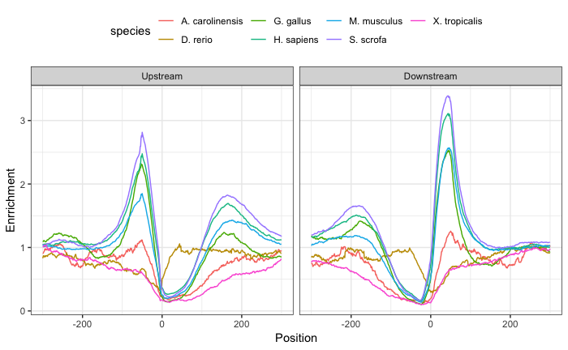

```r
ce10.TOTAL[, species:="C. elegans"]
hg19.TOTAL[, species:="H. sapiens"]
mm10.TOTAL[, species:="M. musculus"]
danRer11.TOTAL[, species:="D. rerio"]
dm6.TOTAL[, species:="D. melanogaster"]
galGal5.TOTAL[, species:="G. gallus"]
sacCer.TOTAL[, species:="S. cerevisiae"]
xenTro9.TOTAL[ , species:="X. tropicalis" ]
anoCar2.TOTAL[  , species:="A. carolinensis" ]
TAIR10.TOTAL[  , species:="A. thaliana" ]
susScr11.TOTAL[ , species:="S. scrofa"]
All.species.TOTAL <- rbind(hg19.TOTAL, mm10.TOTAL, galGal5.TOTAL, danRer11.TOTAL, anoCar2.TOTAL, xenTro9.TOTAL,  susScr11.TOTAL  )
#All.species.TOTAL.binomial <- cbind(All.species.TOTAL,  Gruns.total[, binconf(Occurrences, hg19.nexons) ])
#All.species.TOTAL.binomial[, median:=NULL]
#All.species.TOTAL.binomial[ , median:=median(PointEst), by=c("exon_pos", "species" )]
#All.species.TOTAL.binomial[, `:=`(Enrrichment=PointEst/median, Enrrichment_l=Lower/median, Enrrichment_u=Upper/median)]
Fig6.B <- ggplot(All.species.TOTAL)+
    geom_line(aes(x=Position,y=Enrrichment, color=species)) +
    #   geom_ribbon(aes(x=Position, fill=species, ymin=Enrrichment_l, ymax=Enrrichment_u), alpha=0.3) +
    xlim(c(-300,300)) +
    facet_grid( . ~ exon_pos ) +
  theme(plot.title = element_text(hjust = 0.5)) +
  theme_bw() +
    theme(legend.position = "top", legend.direction = "horizontal")
Fig6.B
```

We plot other species that did not show strong enrichment by separate

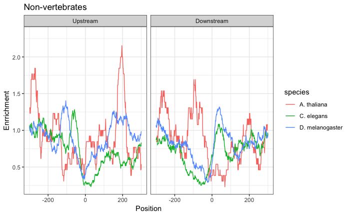

```r
All.species.TOTAL <- rbind(ce10.TOTAL, dm6.TOTAL, TAIR10.TOTAL  )
ggplot(All.species.TOTAL)+
    geom_line(aes(x=Position,y=Enrrichment, color=species)) +
    xlim(c(-300,300)) +
    ggtitle( "Non-vertebrates") +
    facet_grid( . ~ exon_pos ) +
  theme(plot.title = element_text(hjust = 0.5)) +
  theme_bw()
```

# G4 and gene structure

## Flanking intron size

Here we analized the intron size of distribution of exon which are flanked by G4 (on an 100nt window)

```r
intron_size_upstream_non_template  <- rbind(fread('./Intron_size/Introns.hg19_upstream_100nt_window.bed.plus_strand_genome.plus_G4s'),
 fread('./Intron_size/Introns.hg19_upstream_100nt_window.bed.minus_strand_genome.minus_G4s'))
intron_size_downstream_non_template  <- rbind(fread('./Intron_size/Introns.hg19_downstream_100nt_window.bed.plus_strand_genome.plus_G4s'),
 fread('./Intron_size/Introns.hg19_downstream_100nt_window.bed.minus_strand_genome.minus_G4s'))
intron_size_upstream_template  <- rbind(fread('./Intron_size/Introns.hg19_upstream_100nt_window.bed.plus_strand_genome.minus_G4s'),
 fread('./Intron_size/Introns.hg19_upstream_100nt_window.bed.minus_strand_genome.plus_G4s'))
intron_size_downstream_template  <- rbind(fread('./Intron_size/Introns.hg19_downstream_100nt_window.bed.minus_strand_genome.plus_G4s'),
 fread('./Intron_size/Introns.hg19_downstream_100nt_window.bed.plus_strand_genome.minus_G4s'))
intron_size_upstream_non_template[ , `:=`(exon_pos="upstream", strand="non_template") ]
intron_size_downstream_non_template[ , `:=`(exon_pos="downstream", strand="non_template") ]
intron_size_upstream_template[ , `:=`(exon_pos="upstream", strand="template") ]
intron_size_downstream_template[ , `:=`(exon_pos="downstream", strand="template") ]
intron_size_TOTAL <- rbind(intron_size_upstream_non_template, intron_size_downstream_non_template, intron_size_upstream_template, intron_size_downstream_template )
colnames(intron_size_TOTAL) <- c("chrom", "start", "end", "strand", "intron_number", "intron_size", "Transcript", "G4", "exon_pos", "Strand"  )
```

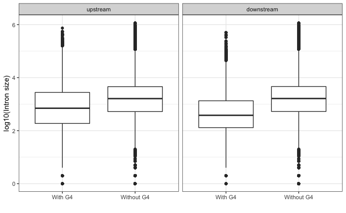

```r
intron_size_TOTAL[  G4>0, G4_type:="With G4" ]
intron_size_TOTAL[  G4==0, G4_type:="Without G4" ]
intron_size_TOTAL$exon_pos <- factor(intron_size_TOTAL$exon_pos, levels=c("upstream", "downstream"))
Fig3.A <- ggplot(data=intron_size_TOTAL) +
  geom_boxplot( aes(x=G4_type, y=log10(intron_size) ) ) +
  facet_grid( . ~  exon_pos ) +
  xlab("")+
  ylab("log10(Intron size)") +
  theme_bw()
Fig3.A
```

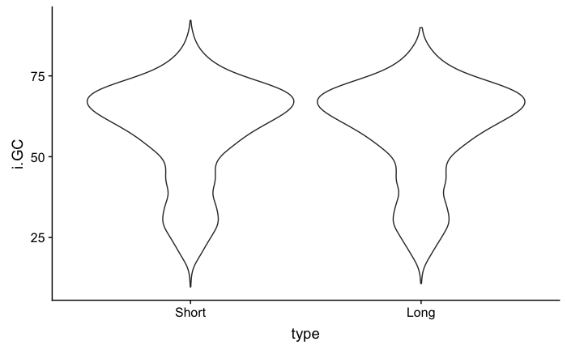

```
Ignoring unknown aesthetics: stat
```

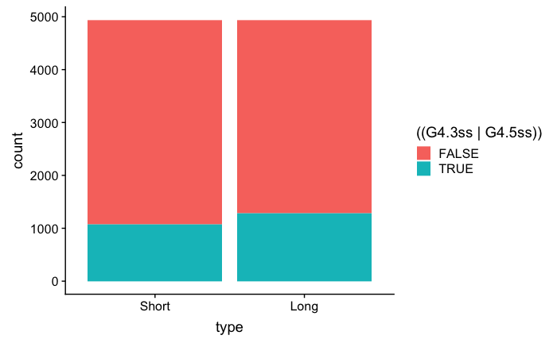

```r
short_introns[, type:="Short"]
long_introns[, type:="Long"]
long_introns$type <- factor(long_introns$type, levels=c("Short", "Long"))
long_short_introns <- rbind(long_introns, short_introns)
ggplot(long_short_introns) +
  geom_violin(aes( type, i.GC))
ggplot(long_short_introns) +
  geom_bar(aes(x=type, fill=((G4.3ss | G4.5ss) ), stat="count" ))
```

## Exon number

Here we explored how G4 enrichments change thorugh gene body

```r
exons_1.up_plus <- read_dist_table("./exon_numbers/exons_1_plus_strand_upstream.txt.score.G4.bed.list.out.num")
exons_1.down_plus <- read_dist_table("./exon_numbers/exons_1_plus_strand_downstream.txt.score.G4.bed.list.out.num")
exons_1.up_minus <- read_dist_table("./exon_numbers/exons_1_minus_strand_upstream.txt.score.G4.bed.list.out.num")
exons_1.down_minus <- read_dist_table("./exon_numbers/exons_1_minus_strand_downstream.txt.score.G4.bed.list.out.num")
exons_1.up_minus[,Position:=Position*-1]
exons_1.down_minus[,Position:=Position*-1]

exons_1.TOTAL <- plot_density(exons_1.up_plus, exons_1.up_minus, exons_1.down_plus, exons_1.down_minus)
```

```r
exons_2.up_plus <- read_dist_table("./exon_numbers/exons_2_plus_strand_upstream.txt.score.G4.bed.list.out.num")
exons_2.down_plus <- read_dist_table("./exon_numbers/exons_2_plus_strand_downstream.txt.score.G4.bed.list.out.num")
exons_2.up_minus <- read_dist_table("./exon_numbers/exons_2_minus_strand_upstream.txt.score.G4.bed.list.out.num")
exons_2.down_minus <- read_dist_table("./exon_numbers/exons_2_minus_strand_downstream.txt.score.G4.bed.list.out.num")
exons_2.up_minus[,Position:=Position*-1]
exons_2.down_minus[,Position:=Position*-1]

exons_2.TOTAL <- plot_density(exons_2.up_plus, exons_2.up_minus, exons_2.down_plus, exons_2.down_minus)
```

```r
exons_3.up_plus <- read_dist_table("./exon_numbers/exons_3_plus_strand_upstream.txt.score.G4.bed.list.out.num")
exons_3.down_plus <- read_dist_table("./exon_numbers/exons_3_plus_strand_downstream.txt.score.G4.bed.list.out.num")
exons_3.up_minus <- read_dist_table("./exon_numbers/exons_3_minus_strand_upstream.txt.score.G4.bed.list.out.num")
exons_3.down_minus <- read_dist_table("./exon_numbers/exons_3_minus_strand_downstream.txt.score.G4.bed.list.out.num")
exons_3.up_minus[,Position:=Position*-1]
exons_3.down_minus[,Position:=Position*-1]

exons_3.TOTAL <- plot_density(exons_3.up_plus, exons_3.up_minus, exons_3.down_plus, exons_3.down_minus)
```

```r
exons_4.up_plus <- read_dist_table("/Users/gp7/Google_Drive/Results/Non_B/exon_numbers/exons_4_plus_strand_upstream.txt.score.G4.bed.list.out.num")
```

```
1 parsing failure.
row col     expected       actual                                                                                                            file
  2  -- 2001 columns 2002 columns '/Users/gp7/Google_Drive/Results/Non_B/exon_numbers/exons_4_plus_strand_upstream.txt.score.G4.bed.list.out.num'
```

```r
exons_4.down_plus <- read_dist_table("/Users/gp7/Google_Drive/Results/Non_B/exon_numbers/exons_4_plus_strand_downstream.txt.score.G4.bed.list.out.num")
```

```
1 parsing failure.
row col     expected       actual                                                                                                              file
  2  -- 2001 columns 2002 columns '/Users/gp7/Google_Drive/Results/Non_B/exon_numbers/exons_4_plus_strand_downstream.txt.score.G4.bed.list.out.num'
```

```r
exons_4.up_minus <- read_dist_table("/Users/gp7/Google_Drive/Results/Non_B/exon_numbers/exons_4_minus_strand_upstream.txt.score.G4.bed.list.out.num")
```

```
1 parsing failure.
row col     expected       actual                                                                                                             file
  2  -- 2001 columns 2002 columns '/Users/gp7/Google_Drive/Results/Non_B/exon_numbers/exons_4_minus_strand_upstream.txt.score.G4.bed.list.out.num'
```

```r
exons_4.down_minus <- read_dist_table("/Users/gp7/Google_Drive/Results/Non_B/exon_numbers/exons_4_minus_strand_downstream.txt.score.G4.bed.list.out.num")
```

```
1 parsing failure.
row col     expected       actual                                                                                                               file
  2  -- 2001 columns 2002 columns '/Users/gp7/Google_Drive/Results/Non_B/exon_numbers/exons_4_minus_strand_downstream.txt.score.G4.bed.list.out.num'
```

```r
exons_4.up_minus[,Position:=Position*-1]
exons_4.down_minus[,Position:=Position*-1]
exons_4.TOTAL <- plot_density(exons_4.up_plus, exons_4.up_minus, exons_4.down_plus, exons_4.down_minus)
```

```r
exons_middle.up_plus <- read_dist_table("/Users/gp7/Google_Drive/Results/Non_B/exon_numbers/exons_middle_plus_strand_upstream.txt.score.G4.bed.list.out.num")
```

```
1 parsing failure.
row col     expected       actual                                                                                                                 file
  2  -- 2001 columns 2002 columns '/Users/gp7/Google_Drive/Results/Non_B/exon_numbers/exons_middle_plus_strand_upstream.txt.score.G4.bed.list.out.num'
```

```r
exons_middle.down_plus <- read_dist_table("/Users/gp7/Google_Drive/Results/Non_B/exon_numbers/exons_middle_plus_strand_downstream.txt.score.G4.bed.list.out.num")
```

```
1 parsing failure.
row col     expected       actual                                                                                                                   file
  2  -- 2001 columns 2002 columns '/Users/gp7/Google_Drive/Results/Non_B/exon_numbers/exons_middle_plus_strand_downstream.txt.score.G4.bed.list.out.num'
```

```r
exons_middle.up_minus <- read_dist_table("/Users/gp7/Google_Drive/Results/Non_B/exon_numbers/exons_middle_minus_strand_upstream.txt.score.G4.bed.list.out.num")
```

```
1 parsing failure.
row col     expected       actual                                                                                                                  file
  2  -- 2001 columns 2002 columns '/Users/gp7/Google_Drive/Results/Non_B/exon_numbers/exons_middle_minus_strand_upstream.txt.score.G4.bed.list.out.num'
```

```r
exons_middle.down_minus <- read_dist_table("/Users/gp7/Google_Drive/Results/Non_B/exon_numbers/exons_middle_minus_strand_downstream.txt.score.G4.bed.list.out.num")
```

```
1 parsing failure.
row col     expected       actual                                                                                                                    file
  2  -- 2001 columns 2002 columns '/Users/gp7/Google_Drive/Results/Non_B/exon_numbers/exons_middle_minus_strand_downstream.txt.score.G4.bed.list.out.num'
```

```r
exons_middle.up_minus[,Position:=Position*-1]
exons_middle.down_minus[,Position:=Position*-1]
exons_middle.TOTAL <- plot_density(exons_middle.up_plus, exons_middle.up_minus, exons_middle.down_plus, exons_middle.down_minus)
```

```r
exons_minus4.up_plus <- read_dist_table("/Users/gp7/Google_Drive/Results/Non_B/exon_numbers/exons_minus4_plus_strand_upstream.txt.score.G4.bed.list.out.num")
```

```
1 parsing failure.
row col     expected       actual                                                                                                                 file
  2  -- 2001 columns 2002 columns '/Users/gp7/Google_Drive/Results/Non_B/exon_numbers/exons_minus4_plus_strand_upstream.txt.score.G4.bed.list.out.num'
```

```r
exons_minus4.down_plus <- read_dist_table("/Users/gp7/Google_Drive/Results/Non_B/exon_numbers/exons_minus4_plus_strand_downstream.txt.score.G4.bed.list.out.num")
```

```
1 parsing failure.
row col     expected       actual                                                                                                                   file
  2  -- 2001 columns 2002 columns '/Users/gp7/Google_Drive/Results/Non_B/exon_numbers/exons_minus4_plus_strand_downstream.txt.score.G4.bed.list.out.num'
```

```r
exons_minus4.up_minus <- read_dist_table("/Users/gp7/Google_Drive/Results/Non_B/exon_numbers/exons_minus4_minus_strand_upstream.txt.score.G4.bed.list.out.num")
```

```
1 parsing failure.
row col     expected       actual                                                                                                                  file
  2  -- 2001 columns 2002 columns '/Users/gp7/Google_Drive/Results/Non_B/exon_numbers/exons_minus4_minus_strand_upstream.txt.score.G4.bed.list.out.num'
```

```r
exons_minus4.down_minus <- read_dist_table("/Users/gp7/Google_Drive/Results/Non_B/exon_numbers/exons_minus4_minus_strand_downstream.txt.score.G4.bed.list.out.num")
```

```
1 parsing failure.
row col     expected       actual                                                                                                                    file
  2  -- 2001 columns 2002 columns '/Users/gp7/Google_Drive/Results/Non_B/exon_numbers/exons_minus4_minus_strand_downstream.txt.score.G4.bed.list.out.num'
```

```r
exons_minus4.up_minus[,Position:=Position*-1]
exons_minus4.down_minus[,Position:=Position*-1]
exons_minus4.TOTAL <- plot_density(exons_minus4.up_plus, exons_minus4.up_minus, exons_minus4.down_plus, exons_minus4.down_minus)
```

```r
exons_minus3.up_plus <- read_dist_table("/Users/gp7/Google_Drive/Results/Non_B/exon_numbers/exons_minus3_plus_strand_upstream.txt.score.G4.bed.list.out.num")
```

```
1 parsing failure.
row col     expected       actual                                                                                                                 file
  2  -- 2001 columns 2002 columns '/Users/gp7/Google_Drive/Results/Non_B/exon_numbers/exons_minus3_plus_strand_upstream.txt.score.G4.bed.list.out.num'
```

```r
exons_minus3.down_plus <- read_dist_table("/Users/gp7/Google_Drive/Results/Non_B/exon_numbers/exons_minus3_plus_strand_downstream.txt.score.G4.bed.list.out.num")
```

```
1 parsing failure.
row col     expected       actual                                                                                                                   file
  2  -- 2001 columns 2002 columns '/Users/gp7/Google_Drive/Results/Non_B/exon_numbers/exons_minus3_plus_strand_downstream.txt.score.G4.bed.list.out.num'
```

```r
exons_minus3.up_minus <- read_dist_table("/Users/gp7/Google_Drive/Results/Non_B/exon_numbers/exons_minus3_minus_strand_upstream.txt.score.G4.bed.list.out.num")
```

```
1 parsing failure.
row col     expected       actual                                                                                                                  file
  2  -- 2001 columns 2002 columns '/Users/gp7/Google_Drive/Results/Non_B/exon_numbers/exons_minus3_minus_strand_upstream.txt.score.G4.bed.list.out.num'
```

```r
exons_minus3.down_minus <- read_dist_table("/Users/gp7/Google_Drive/Results/Non_B/exon_numbers/exons_minus3_minus_strand_downstream.txt.score.G4.bed.list.out.num")
```

```
1 parsing failure.
row col     expected       actual                                                                                                                    file
  2  -- 2001 columns 2002 columns '/Users/gp7/Google_Drive/Results/Non_B/exon_numbers/exons_minus3_minus_strand_downstream.txt.score.G4.bed.list.out.num'
```

```r
exons_minus3.up_minus[,Position:=Position*-1]
exons_minus3.down_minus[,Position:=Position*-1]
exons_minus3.TOTAL <- plot_density(exons_minus3.up_plus, exons_minus3.up_minus, exons_minus3.down_plus, exons_minus3.down_minus)
```

```r
exons_minus2.up_plus <- read_dist_table("/Users/gp7/Google_Drive/Results/Non_B/exon_numbers/exons_minus2_plus_strand_upstream.txt.score.G4.bed.list.out.num")
```

```
1 parsing failure.
row col     expected       actual                                                                                                                 file
  2  -- 2001 columns 2002 columns '/Users/gp7/Google_Drive/Results/Non_B/exon_numbers/exons_minus2_plus_strand_upstream.txt.score.G4.bed.list.out.num'
```

```r
exons_minus2.down_plus <- read_dist_table("/Users/gp7/Google_Drive/Results/Non_B/exon_numbers/exons_minus2_plus_strand_downstream.txt.score.G4.bed.list.out.num")
```

```
1 parsing failure.
row col     expected       actual                                                                                                                   file
  2  -- 2001 columns 2002 columns '/Users/gp7/Google_Drive/Results/Non_B/exon_numbers/exons_minus2_plus_strand_downstream.txt.score.G4.bed.list.out.num'
```

```r
exons_minus2.up_minus <- read_dist_table("/Users/gp7/Google_Drive/Results/Non_B/exon_numbers/exons_minus2_minus_strand_upstream.txt.score.G4.bed.list.out.num")
```

```
1 parsing failure.
row col     expected       actual                                                                                                                  file
  2  -- 2001 columns 2002 columns '/Users/gp7/Google_Drive/Results/Non_B/exon_numbers/exons_minus2_minus_strand_upstream.txt.score.G4.bed.list.out.num'
```

```r
exons_minus2.down_minus <- read_dist_table("/Users/gp7/Google_Drive/Results/Non_B/exon_numbers/exons_minus2_minus_strand_downstream.txt.score.G4.bed.list.out.num")
```

```
1 parsing failure.
row col     expected       actual                                                                                                                    file
  2  -- 2001 columns 2002 columns '/Users/gp7/Google_Drive/Results/Non_B/exon_numbers/exons_minus2_minus_strand_downstream.txt.score.G4.bed.list.out.num'
```

```r
exons_minus2.up_minus[,Position:=Position*-1]
exons_minus2.down_minus[,Position:=Position*-1]
exons_minus2.TOTAL <- plot_density(exons_minus2.up_plus, exons_minus2.up_minus, exons_minus2.down_plus, exons_minus2.down_minus)
```

```r
exons_minus1.up_plus <- read_dist_table("/Users/gp7/Google_Drive/Results/Non_B/exon_numbers/exons_minus1_plus_strand_upstream.txt.score.G4.bed.list.out.num")
```

```
1 parsing failure.
row col     expected       actual                                                                                                                 file
  2  -- 2001 columns 2002 columns '/Users/gp7/Google_Drive/Results/Non_B/exon_numbers/exons_minus1_plus_strand_upstream.txt.score.G4.bed.list.out.num'
```

```r
exons_minus1.down_plus <- read_dist_table("/Users/gp7/Google_Drive/Results/Non_B/exon_numbers/exons_minus1_plus_strand_downstream.txt.score.G4.bed.list.out.num")
```

```
1 parsing failure.
row col     expected       actual                                                                                                                   file
  2  -- 2001 columns 2002 columns '/Users/gp7/Google_Drive/Results/Non_B/exon_numbers/exons_minus1_plus_strand_downstream.txt.score.G4.bed.list.out.num'
```

```r
exons_minus1.up_minus <- read_dist_table("/Users/gp7/Google_Drive/Results/Non_B/exon_numbers/exons_minus1_minus_strand_upstream.txt.score.G4.bed.list.out.num")
```

```
1 parsing failure.
row col     expected       actual                                                                                                                  file
  2  -- 2001 columns 2002 columns '/Users/gp7/Google_Drive/Results/Non_B/exon_numbers/exons_minus1_minus_strand_upstream.txt.score.G4.bed.list.out.num'
```

```r
exons_minus1.down_minus <- read_dist_table("/Users/gp7/Google_Drive/Results/Non_B/exon_numbers/exons_minus1_minus_strand_downstream.txt.score.G4.bed.list.out.num")
```

```
1 parsing failure.
row col     expected       actual                                                                                                                    file
  2  -- 2001 columns 2002 columns '/Users/gp7/Google_Drive/Results/Non_B/exon_numbers/exons_minus1_minus_strand_downstream.txt.score.G4.bed.list.out.num'
```

```r
exons_minus1.up_minus[,Position:=Position*-1]
exons_minus1.down_minus[,Position:=Position*-1]
exons_minus1.TOTAL <- plot_density(exons_minus1.up_plus, exons_minus1.up_minus, exons_minus1.down_plus, exons_minus1.down_minus)
```

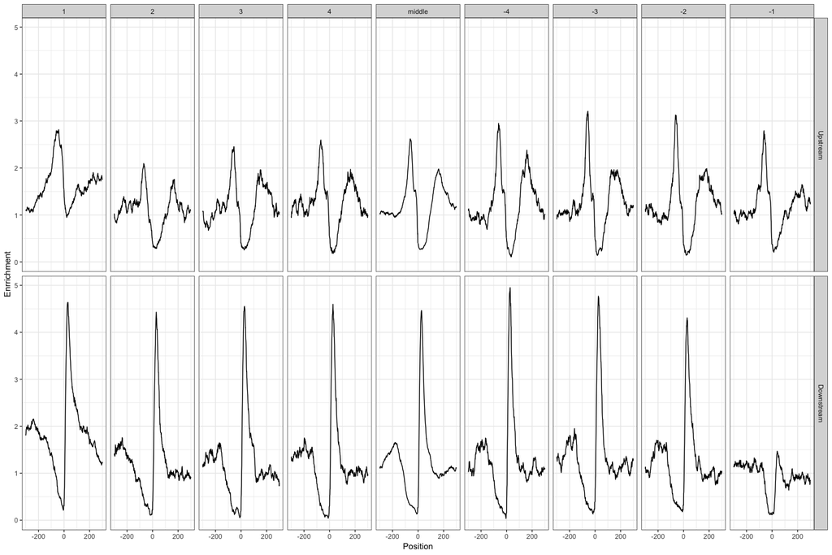

```r
exons_1.TOTAL[, exon_num:="1"]
exons_2.TOTAL[, exon_num:="2"]
exons_3.TOTAL[, exon_num:="3"]
exons_4.TOTAL[, exon_num:="4"]
exons_middle.TOTAL[, exon_num:="middle"]
exons_minus4.TOTAL[, exon_num:="-4"]
exons_minus3.TOTAL[, exon_num:="-3"]
exons_minus2.TOTAL[, exon_num:="-2"]
exons_minus1.TOTAL[, exon_num:="-1"]
exon_num.TOTAL <- rbind(exons_1.TOTAL, exons_2.TOTAL, exons_3.TOTAL, exons_4.TOTAL, exons_middle.TOTAL, exons_minus4.TOTAL, exons_minus3.TOTAL, exons_minus2.TOTAL, exons_minus1.TOTAL)
exon_num.TOTAL$exon_num <- factor(exon_num.TOTAL$exon_num, levels = c("1", "2", "3", "4", "middle", "-4", "-3", "-2", "-1" ))
ggplot(exon_num.TOTAL)+
    geom_line(aes(x=Position,y=Enrrichment)) +
    xlim(c(-300,300)) +
    facet_grid( exon_pos ~ exon_num   ) +
  theme_bw()
```

# G4 seq

Here we distribution of G4-seq experiments

```r
G4_2019.K.Q1_up_plus <- read_dist_table("./G4_seq_2019/exon.up_plus.q1.bed.score.GSM3003539_Homo_all_w15_th-1_plus_minus.hits.max.K.w50.25.bed.bed.list.out.num")
G4_2019.K.Q2_up_plus <- read_dist_table("./G4_seq_2019/exon.up_plus.q2.bed.score.GSM3003539_Homo_all_w15_th-1_plus_minus.hits.max.K.w50.25.bed.bed.list.out.num")
G4_2019.K.Q3_up_plus <- read_dist_table("./G4_seq_2019/exon.up_plus.q3.bed.score.GSM3003539_Homo_all_w15_th-1_plus_minus.hits.max.K.w50.25.bed.bed.list.out.num")
```

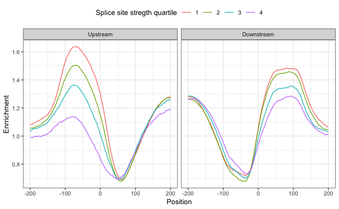

```r
G4_2019.PDS.Q1_up_plus <- read_dist_table("./G4_seq_2019/exon.up_plus.q1.bed.score.GSM3003540_Homo_all_w15_th-1_plus_minus.hits.max.PDS.w50.35.bed.bed.list.out.num")
G4_2019.PDS.Q2_up_plus <- read_dist_table("./G4_seq_2019/exon.up_plus.q2.bed.score.GSM3003540_Homo_all_w15_th-1_plus_minus.hits.max.PDS.w50.35.bed.bed.list.out.num")
G4_2019.PDS.Q3_up_plus <- read_dist_table("./G4_seq_2019/exon.up_plus.q3.bed.score.GSM3003540_Homo_all_w15_th-1_plus_minus.hits.max.PDS.w50.35.bed.bed.list.out.num")
G4_2019.PDS.Q4_up_plus <- read_dist_table("./G4_seq_2019/exon.up_plus.q4.bed.score.GSM3003540_Homo_all_w15_th-1_plus_minus.hits.max.PDS.w50.35.bed.bed.list.out.num")
G4_2019.PDS.Q1_down_plus <- read_dist_table("./G4_seq_2019/exon.down_plus.q1.bed.score.GSM3003540_Homo_all_w15_th-1_plus_minus.hits.max.PDS.w50.35.bed.bed.list.out.num")
G4_2019.PDS.Q2_down_plus <- read_dist_table("./G4_seq_2019/exon.down_plus.q2.bed.score.GSM3003540_Homo_all_w15_th-1_plus_minus.hits.max.PDS.w50.35.bed.bed.list.out.num")
G4_2019.PDS.Q3_down_plus <- read_dist_table("./G4_seq_2019/exon.down_plus.q3.bed.score.GSM3003540_Homo_all_w15_th-1_plus_minus.hits.max.PDS.w50.35.bed.bed.list.out.num")
G4_2019.PDS.Q4_down_plus <- read_dist_table("./G4_seq_2019/exon.down_plus.q4.bed.score.GSM3003540_Homo_all_w15_th-1_plus_minus.hits.max.PDS.w50.35.bed.bed.list.out.num")
G4_2019.PDS.Q1_up_minus <- read_dist_table("./G4_seq_2019/exon.up_minus.q1.bed.score.GSM3003540_Homo_all_w15_th-1_plus_minus.hits.max.PDS.w50.35.bed.bed.list.out.num")
G4_2019.PDS.Q2_up_minus <- read_dist_table("./G4_seq_2019/exon.up_minus.q2.bed.score.GSM3003540_Homo_all_w15_th-1_plus_minus.hits.max.PDS.w50.35.bed.bed.list.out.num")
G4_2019.PDS.Q3_up_minus <- read_dist_table("./G4_seq_2019/exon.up_minus.q3.bed.score.GSM3003540_Homo_all_w15_th-1_plus_minus.hits.max.PDS.w50.35.bed.bed.list.out.num")
G4_2019.PDS.Q4_up_minus <- read_dist_table("./G4_seq_2019/exon.up_minus.q4.bed.score.GSM3003540_Homo_all_w15_th-1_plus_minus.hits.max.PDS.w50.35.bed.bed.list.out.num")
G4_2019.PDS.Q1_down_minus <- read_dist_table("./G4_seq_2019/exon.down_minus.q1.bed.score.GSM3003540_Homo_all_w15_th-1_plus_minus.hits.max.PDS.w50.35.bed.bed.list.out.num")
G4_2019.PDS.Q2_down_minus <- read_dist_table("./G4_seq_2019/exon.down_minus.q2.bed.score.GSM3003540_Homo_all_w15_th-1_plus_minus.hits.max.PDS.w50.35.bed.bed.list.out.num")
G4_2019.PDS.Q3_down_minus <- read_dist_table("./G4_seq_2019/exon.down_minus.q3.bed.score.GSM3003540_Homo_all_w15_th-1_plus_minus.hits.max.PDS.w50.35.bed.bed.list.out.num")
G4_2019.PDS.Q4_down_minus <- read_dist_table("./G4_seq_2019/exon.down_minus.q4.bed.score.GSM3003540_Homo_all_w15_th-1_plus_minus.hits.max.PDS.w50.35.bed.bed.list.out.num")
G4_2019.PDS.Qs.plus.up.list <- list(G4_2019.PDS.Q1_up_plus, G4_2019.PDS.Q2_up_plus, G4_2019.PDS.Q3_up_plus, G4_2019.PDS.Q4_up_plus)
G4_2019.PDS.Qs.minus.list <- list(G4_2019.PDS.Q1_up_minus, G4_2019.PDS.Q2_up_minus, G4_2019.PDS.Q3_up_minus, G4_2019.PDS.Q4_up_minus)
G4_2019.PDS.Qs.plus.down.list <- list(G4_2019.PDS.Q1_down_plus, G4_2019.PDS.Q2_down_plus, G4_2019.PDS.Q3_down_plus, G4_2019.PDS.Q4_down_plus)
G4_2019.PDS.Qs.minus.down.list <- list(G4_2019.PDS.Q1_down_minus, G4_2019.PDS.Q2_down_minus, G4_2019.PDS.Q3_down_minus, G4_2019.PDS.Q4_down_minus)
G4_2019.PDS.window_len = 2000
G4_2019.PDS.Qs.total <- get_total_Qs(G4_2019.PDS.Qs.plus.up.list, G4_2019.PDS.Qs.minus.list, G4_2019.PDS.Qs.plus.down.list, G4_2019.PDS.Qs.minus.down.list, G4_2019.PDS.window_len)
ggplot(G4_2019.PDS.Qs.total)+
  geom_line(aes(x=Position,y=Enrrichment, colour=Q)) +
  xlim(c(-200,200)) +
  facet_grid( . ~ exon_pos ) +
  theme(text = element_text(size=15)) +
  theme_bw() +
  labs(colour = "Splice site stregth quartile") +
  theme(legend.position = "top", legend.direction = "horizontal")
```

```r
G4_2019.template.PDS.Q1_up_plus <- read_dist_table("./G4_seq_2019/exon.up_plus.q1.bed.score.GSM3003540_Homo_all_w15_th-1_minus.hits.max.PDS.w50.35.bed.bed.list.out.num")
G4_2019.template.PDS.Q2_up_plus <- read_dist_table("./G4_seq_2019/exon.up_plus.q2.bed.score.GSM3003540_Homo_all_w15_th-1_minus.hits.max.PDS.w50.35.bed.bed.list.out.num")
G4_2019.template.PDS.Q3_up_plus <- read_dist_table("./G4_seq_2019/exon.up_plus.q3.bed.score.GSM3003540_Homo_all_w15_th-1_minus.hits.max.PDS.w50.35.bed.bed.list.out.num")
G4_2019.template.PDS.Q4_up_plus <- read_dist_table("./G4_seq_2019/exon.up_plus.q4.bed.score.GSM3003540_Homo_all_w15_th-1_minus.hits.max.PDS.w50.35.bed.bed.list.out.num")
G4_2019.template.PDS.Q1_up_minus <- read_dist_table("./G4_seq_2019/exon.up_minus.q1.bed.score.GSM3003540_Homo_all_w15_th-1_plus.hits.max.PDS.w50.35.bed.bed.list.out.num")
G4_2019.template.PDS.Q2_up_minus <- read_dist_table("./G4_seq_2019/exon.up_minus.q2.bed.score.GSM3003540_Homo_all_w15_th-1_plus.hits.max.PDS.w50.35.bed.bed.list.out.num")
G4_2019.template.PDS.Q3_up_minus <- read_dist_table("./G4_seq_2019/exon.up_minus.q3.bed.score.GSM3003540_Homo_all_w15_th-1_plus.hits.max.PDS.w50.35.bed.bed.list.out.num")
G4_2019.template.PDS.Q4_up_minus <- read_dist_table("./G4_seq_2019/exon.up_minus.q4.bed.score.GSM3003540_Homo_all_w15_th-1_plus.hits.max.PDS.w50.35.bed.bed.list.out.num")
G4_2019.non_template.PDS.Q1_up_plus <- read_dist_table("./G4_seq_2019/exon.up_plus.q1.bed.score.GSM3003540_Homo_all_w15_th-1_plus.hits.max.PDS.w50.35.bed.bed.list.out.num")
G4_2019.non_template.PDS.Q2_up_plus <- read_dist_table("./G4_seq_2019/exon.up_plus.q2.bed.score.GSM3003540_Homo_all_w15_th-1_plus.hits.max.PDS.w50.35.bed.bed.list.out.num")
G4_2019.non_template.PDS.Q3_up_plus <- read_dist_table("./G4_seq_2019/exon.up_plus.q3.bed.score.GSM3003540_Homo_all_w15_th-1_plus.hits.max.PDS.w50.35.bed.bed.list.out.num")
G4_2019.non_template.PDS.Q4_up_plus <- read_dist_table("./G4_seq_2019/exon.up_plus.q4.bed.score.GSM3003540_Homo_all_w15_th-1_plus.hits.max.PDS.w50.35.bed.bed.list.out.num")
G4_2019.non_template.PDS.Q1_up_minus <- read_dist_table("./G4_seq_2019/exon.up_minus.q1.bed.score.GSM3003540_Homo_all_w15_th-1_minus.hits.max.PDS.w50.35.bed.bed.list.out.num")
G4_2019.non_template.PDS.Q2_up_minus <- read_dist_table("./G4_seq_2019/exon.up_minus.q2.bed.score.GSM3003540_Homo_all_w15_th-1_minus.hits.max.PDS.w50.35.bed.bed.list.out.num")
G4_2019.non_template.PDS.Q3_up_minus <- read_dist_table("./G4_seq_2019/exon.up_minus.q3.bed.score.GSM3003540_Homo_all_w15_th-1_minus.hits.max.PDS.w50.35.bed.bed.list.out.num")
G4_2019.non_template.PDS.Q4_up_minus <- read_dist_table("./G4_seq_2019/exon.up_minus.q4.bed.score.GSM3003540_Homo_all_w15_th-1_minus.hits.max.PDS.w50.35.bed.bed.list.out.num")
G4_2019.template.PDS.Q1_down_plus <- read_dist_table("./G4_seq_2019/exon.down_plus.q1.bed.score.GSM3003540_Homo_all_w15_th-1_minus.hits.max.PDS.w50.35.bed.bed.list.out.num")
G4_2019.template.PDS.Q2_down_plus <- read_dist_table("./G4_seq_2019/exon.down_plus.q2.bed.score.GSM3003540_Homo_all_w15_th-1_minus.hits.max.PDS.w50.35.bed.bed.list.out.num")
G4_2019.template.PDS.Q3_down_plus <- read_dist_table("./G4_seq_2019/exon.down_plus.q3.bed.score.GSM3003540_Homo_all_w15_th-1_minus.hits.max.PDS.w50.35.bed.bed.list.out.num")
G4_2019.template.PDS.Q4_down_plus <- read_dist_table("./G4_seq_2019/exon.down_plus.q4.bed.score.GSM3003540_Homo_all_w15_th-1_minus.hits.max.PDS.w50.35.bed.bed.list.out.num")
G4_2019.template.PDS.Q1_down_minus <- read_dist_table("./G4_seq_2019/exon.down_minus.q1.bed.score.GSM3003540_Homo_all_w15_th-1_plus.hits.max.PDS.w50.35.bed.bed.list.out.num")
G4_2019.template.PDS.Q2_down_minus <- read_dist_table("./G4_seq_2019/exon.down_minus.q2.bed.score.GSM3003540_Homo_all_w15_th-1_plus.hits.max.PDS.w50.35.bed.bed.list.out.num")
G4_2019.template.PDS.Q3_down_minus <- read_dist_table("./G4_seq_2019/exon.down_minus.q3.bed.score.GSM3003540_Homo_all_w15_th-1_plus.hits.max.PDS.w50.35.bed.bed.list.out.num")
G4_2019.template.PDS.Q4_down_minus <- read_dist_table("./G4_seq_2019/exon.down_minus.q4.bed.score.GSM3003540_Homo_all_w15_th-1_plus.hits.max.PDS.w50.35.bed.bed.list.out.num")
G4_2019.non_template.PDS.Q1_down_plus <- read_dist_table("./G4_seq_2019/exon.down_plus.q1.bed.score.GSM3003540_Homo_all_w15_th-1_plus.hits.max.PDS.w50.35.bed.bed.list.out.num")
G4_2019.non_template.PDS.Q2_down_plus <- read_dist_table("./G4_seq_2019/exon.down_plus.q2.bed.score.GSM3003540_Homo_all_w15_th-1_plus.hits.max.PDS.w50.35.bed.bed.list.out.num")
G4_2019.non_template.PDS.Q3_down_plus <- read_dist_table("./G4_seq_2019/exon.down_plus.q3.bed.score.GSM3003540_Homo_all_w15_th-1_plus.hits.max.PDS.w50.35.bed.bed.list.out.num")
G4_2019.non_template.PDS.Q4_down_plus <- read_dist_table("./G4_seq_2019/exon.down_plus.q4.bed.score.GSM3003540_Homo_all_w15_th-1_plus.hits.max.PDS.w50.35.bed.bed.list.out.num")
G4_2019.non_template.PDS.Q1_down_minus <- read_dist_table("./G4_seq_2019/exon.down_minus.q1.bed.score.GSM3003540_Homo_all_w15_th-1_minus.hits.max.PDS.w50.35.bed.bed.list.out.num")
G4_2019.non_template.PDS.Q2_down_minus <- read_dist_table("./G4_seq_2019/exon.down_minus.q2.bed.score.GSM3003540_Homo_all_w15_th-1_minus.hits.max.PDS.w50.35.bed.bed.list.out.num")
G4_2019.non_template.PDS.Q3_down_minus <- read_dist_table("./G4_seq_2019/exon.down_minus.q3.bed.score.GSM3003540_Homo_all_w15_th-1_minus.hits.max.PDS.w50.35.bed.bed.list.out.num")
G4_2019.non_template.PDS.Q4_down_minus <- read_dist_table("./G4_seq_2019/exon.down_minus.q4.bed.score.GSM3003540_Homo_all_w15_th-1_minus.hits.max.PDS.w50.35.bed.bed.list.out.num")
```

```r
G4_2019.template.PDS.Qs.plus.up.list <- list(G4_2019.template.PDS.Q1_up_plus, G4_2019.template.PDS.Q2_up_plus, G4_2019.template.PDS.Q3_up_plus, G4_2019.template.PDS.Q4_up_plus)
G4_2019.template.PDS.Qs.minus.list <- list(G4_2019.template.PDS.Q1_up_minus, G4_2019.template.PDS.Q2_up_minus, G4_2019.template.PDS.Q3_up_minus, G4_2019.template.PDS.Q4_up_minus)
G4_2019.template.PDS.Qs.plus.down.list <- list(G4_2019.template.PDS.Q1_down_plus, G4_2019.template.PDS.Q2_down_plus, G4_2019.template.PDS.Q3_down_plus, G4_2019.template.PDS.Q4_down_plus)
G4_2019.template.PDS.Qs.minus.down.list <- list(G4_2019.template.PDS.Q1_down_minus, G4_2019.template.PDS.Q2_down_minus, G4_2019.template.PDS.Q3_down_minus, G4_2019.template.PDS.Q4_down_minus)
G4_2019.template.PDS.window_len = 2000
G4_2019.template.PDS.Qs.total <- get_total_Qs(G4_2019.template.PDS.Qs.plus.up.list, G4_2019.template.PDS.Qs.minus.list, G4_2019.template.PDS.Qs.plus.down.list, G4_2019.template.PDS.Qs.minus.down.list, window_len)
```

```
Error in seq(nrow(Total_Qs)/window_len) : object 'window_len' not found
```

# KCl RNA-seq

As K+ is known to stabilize G4, we analized (RNA-seq data)[https://www.ncbi.nlm.nih.gov/bioproject/PRJEB19451] comming from neurons after 4-hour KCl-indused depolarization.

We use chi-squared test to calculate the significance

```r
human.exons.downstream.G4s <- fread("../Exons_G4s/human.exons.tvs.downstream.G4seq_PDS")
colnames(human.exons.downstream.G4s) <- c( "chrom", "sstart", "send", "sstrand", "start", "end", "strand",  "gchrom", "gstart", "gend", "gscore", "exon_dist"  )
human.exons.downstream.G4s[ ,dist:=( (gstart + (gend- gstart)/2) - sstart) ]
human.exons.downstream.G4s[ sstrand=="-", dist:=(   sstart - (gstart + (gend- gstart)/2)) ]
human.exons.downstream.G4s[, exon_len:=end-start]
human.exons.downstream.G4s[ , G4_bol:="Without G-quadruplex"]
human.exons.downstream.G4s[ dist<=100  & dist>=0 , G4_bol:="With G-quadruplex"]
human.exons.downstream.G4s[, exon_class:="exon"]
human.exons.downstream.G4s[ exon_len<=30, exon_class:="microexon"]
human.exons.downstream.G4s.2x2 <- matrix(ncol = 2,
c(nrow(human.exons.downstream.G4s[ exon_class=="exon" & G4_bol=="Without G-quadruplex"]),
nrow(human.exons.downstream.G4s[ exon_class=="exon" & G4_bol=="With G-quadruplex"]),
nrow(human.exons.downstream.G4s[ exon_class=="microexon" & G4_bol=="Without G-quadruplex"]),
nrow(human.exons.downstream.G4s[ exon_class=="microexon" & G4_bol=="With G-quadruplex"]) ))
chisq.test(human.exons.downstream.G4s.2x2)
```

```
    Pearson's Chi-squared test with Yates' continuity correction

data:  human.exons.downstream.G4s.2x2
X-squared = 8.2286, df = 1, p-value = 0.004123
```

# AQ1

# PDS

### G4seq